# beatochess no. 14 (November 2025)

Beat Neuenschwander, neuenschwander.beat@gmail.com, https://github.com/beatochess/

I would like to thank Jaroslav Polasek and Volker Hergert for the their contributions to this issue of **beatochess**. Jaroslav pointed out an error on my part in the last issue and sent me his own correction of the **Isenegger +0612.10g2e2 (1944)** study. As you can see below, Volker was very busy in commenting and revising studies.

For this issue my focus has been on commenting and revising studies by Isenegger that have been included in Harold’s **HHdbVI** database. You can access the pgn file of all his studies, including the findings in **beatochess-13/14**, here:

[Isenegger-studies](https://github.com/beatochess/beatochess-issues/tree/main/pgn/pgn-collections)

# 1 beatochess-13: erratum

## 1.1 Isenegger +0612.10g2e2 (1944) corrections

Jaroslav Polasek (JP) informed me that my correction of the Isenegger +0612.10 study is not correct. I checked this and realized that I picked the wrong study.

Below are all corrections: the one I intended for beatochess-13, the one by Volker (from beatochess-13), and a new one kindly provided by Jaroslav. Jaroslav also informed me that he is working on a version with richter content, which he will publish in **EG**. Stay tuned…

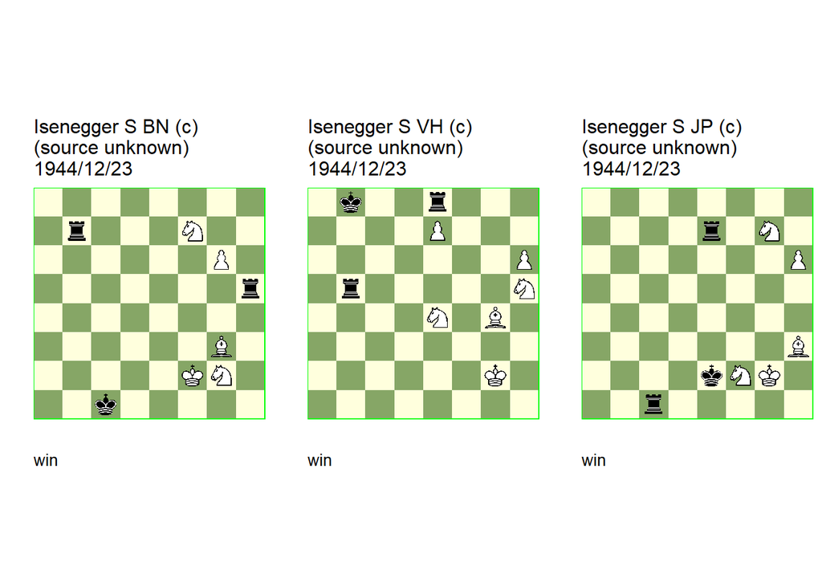

GBR: +0612.10f2c1 (c) FEN: 8/1r3N2/6P1/7r/8/6B1/5KN1/2k5 w - - 0 1

correction: Neuenschwander=B beatochess 10/11/2025. **1. Bf4+ Kb1 2. g7 Rg5 3. Bxg5 Rxf7+ 4. Bf6 Rxf6+ 5. Nf4 Rxf4+ 6. Kg3 Rf1 7. Kg2** (7. Kh2 or ) **1-0**.

GBR: +0612.20g2b8 (c) FEN: 1k2r3/4P3/7P/1r5N/4N1B1/8/6K1/8 w - - 0 1

correction: Hergert=V beatochess 30/10/2025. **1. Ng7! Rxe7 2. h7 Rh5! 3. Bxh5** (3. Nxh5? Rxh7!1) **3… Rxg7+ 4. Ng5!** (4. Ng3? Rxh7!1) **4… Rxg5+ 5. Bg4! Rxg4+ 6. Kh3 1-0**.

GBR: +0612.10g2e2 (c) FEN: 8/4r1N1/7P/8/8/7B/4kNK1/2r5 w - - 0 1

correction: Polasek=J beatochess 10/11/2025. **1. Bg4+ Kd2 2. h7 Rc8 3. Ne4+ Kc1 4. Bxc8 Rxg7+ 5. Ng5 Rxg5+ 6. Bg4 Rxg4+ 7. Kh3 Rg1 8. Kh2 1-0**.

# 2 Isenegger

## 2.1 Comments on studies in HHdbVI

### 2.1.1 Isenegger +0040.33e1d3 (1939). Cooks

The study is cooked in multiple ways.

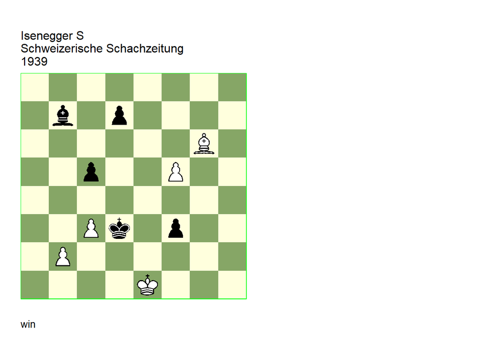

GBR: +0040.33e1d3 U2 FEN: 8/1b1p4/6B1/2p2P2/8/2Pk1p2/1P6/4K3 w - - 0 1

Schweizerische Schachzeitung=2 Schweizerische Schachzeitung/2 U2: Neuenschwander=B beatochess 04/11/2025, U2: Hergert=V beatochess 27/11/2025. **1. Kf2!** (1. f6+? Ke3) **1… Be4** (1… Bd5 2. f6+ Kd2 3. f7 Bxf7 4. Bxf7 Kc2 5. b4) **2. Bh7! Bd5** (2… Kd2 3. f6 Bd5 4. Bg6 Kc1 5. b4) **3. f6+ Kc4** (3… Kd2 4. Bg6) **4. Bb1!** (4. Bc2! **cook** VH ) **4… Kb3** (4… Kb5 main 5. c4+! (5. Bg6 **cook** **BN** ) (5. Ke3 **cook** **BN** ) 5… Kxc4 (5… Bxc4 main 6. Bd3! Bxd3 7. f7) 6. Ba2+ Kd4 7. Bxd5) **5. Ba2+! Kxa2 6. b4! Kb3 7. b5! Kxc3** eg **8. b6 Kd3** (8… Kc2 9. b7! Bxb7 10. f7 c4 11. f8=Q c3 12. Qf5+ Kc1 13. Qxd7) **9. f7 Bxf7 10. b7 c4 11. b8=Q c3 12. Qd6+ 1-0**.

### 2.1.2 Isenegger +0071.64c8g8 (1939). Duals, modification

Unfortunately the pawn sacrifice **b5** works on the first or second move as well.

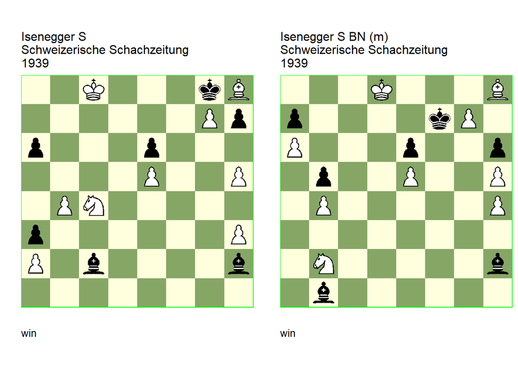

GBR: +0071.64c8g8 (U1) (U2) FEN: 2K3kB/6Pp/p3p3/4P2P/1PN5/p6P/P1b4b/8 w - - 0 1

Schweizerische Schachzeitung=5 Schweizerische Schachzeitung/5. (U1/U2): Neuenschwander=B beatochess 04/11/2025. **1. Ne3!** (1. b5! **dual** **BN** 1… axb5 2. Ne3 etc. (move order **dual** ) 1… Bf5 2. Nxf5 (2. b5! **dual** **BN** 2… axb5 3. Nxf5 etc. (move order **dual**) ) 2… exf5 3. e6 Bd6 4. b5! axb5 5. Kd7 Bb4 6. Kc6 f4 7. Kxb5! Be7 8. Kc4 f3 9. Kd3 f2 10. Ke2 Bc5 11. Kf1! (11. e7? Bxe7) 11… h6 12. Kg2 Kh7 13. g8=Q+ Kxg8 14. Bf6 Kf8 15. Bh4 Ke8 16. Bxf2 Bxf2 17. Kxf2 Ke7 18. Ke3 Kxe6 19. Kd4 1-0**.

GBR: +0071.64d8f7 (m) FEN: 3K3B/p4kP1/P3p2p/1p2P2P/1P5P/8/1N5b/1b6 w - - 0 1

modification: Neuenschwander=B beatochess 04/11/2025. **1. Nd1 Kg8 2. Ne3** (2. Nc3? Bd3 -+) (2. Nf2? Bf5 -+) **2… Bf5** (2… Bxe5 3. Ng4 Bxg7 4. Bxg7 Kxg7 5. Kc7 +-) **3. Nxf5 exf5 4. e6 Bd6 5. Kd7 Bxb4 6. Kc6 f4 7. Kxb5 Be7 8. Kc4 f3 9. Kd3 f2 10. Ke2 Bc5 11. Kf1 Kh7 12. e7! Bxe7 13. g8=Q+! Kxg8 14. Bd4 1-0**.

### 2.1.3 Isenegger +3412.36g6d5 (1939). Cook(s)

**9. Rd3!** is a another cook in the original study, and it also cooks the correction.

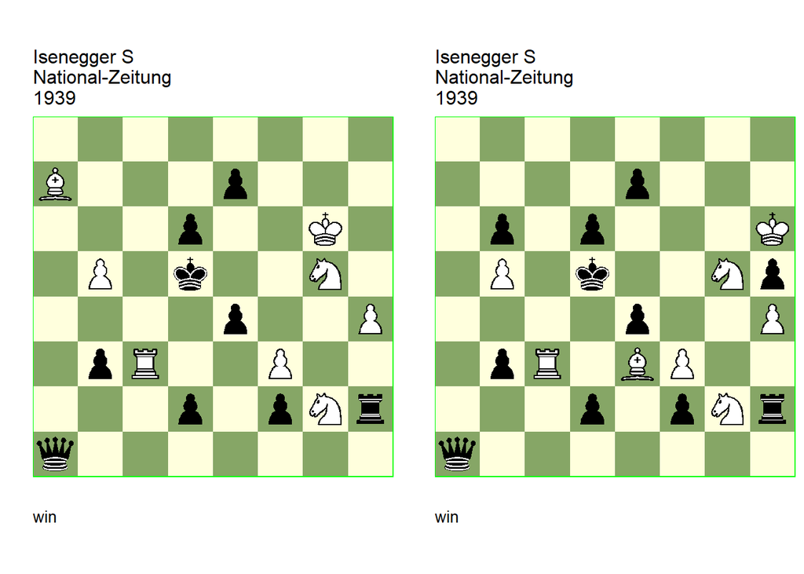

GBR: +3412.36g6d5 U2 FEN: 8/B3p3/3p2K1/1P1k2N1/4p2P/1pR2P2/3p1pNr/q7 w - - 0 1

U2?: Kolb=F Schweizerische Schachzeitung=10 10/1941 U2: Garcia=M HHdbV#65483 24-9-2011. U2 Neuenschwander=B beatochess 13/09/2025. **1. Nf4+ Ke5 2. Be3! exf3** (2… Rg2 3. Rc7! Qa7! 4. Rxa7 d5 5. Ra1! b2 6. Rd1 Rg1 7. Ne2!) **3. Nd3+ Kd5 4. Nb4+ Ke5 5. Nc6+ Kd5 6. Nxe7+ Ke5 7. Nc6+** (7. Rc4! **cook** MG 7… Qb1+ 8. Kg7 Rxh4 9. Rxh4 d1=Q 10. Bxf2 Qh7+ 11. Nxh7 d5 12. Nf8) **7… Kd5 8. Nb4+ Ke5 9. Nd3+** (9. Rd3 **cook** **BN** ) **9… Kd5 10. Nf4+ Ke5 11. Nf7+ Ke4 12. Nxd6+ Ke5 13. Nc4+ Ke4 14. Nxd2+ Ke5 15. Nc4+ Ke4 16. Nd6+ Ke5 17. Nf7+ Ke4 18. Ng5+ Ke5 19. Rd3! Qa8 20. Nf7+ Ke4 21. Nd6+ Ke5 22. Nc4+ Ke4 23. Rd4# 1-0**.

GBR: +3412.38h6d5 (c) U2 FEN: 8/4p3/1p1p3K/1P1k2Np/4p2P/1pR1BP2/3p1pNr/q7 w - - 0 1

correction: Schweizerische Schachzeitung=10 10/1941. U2: Neuenschwander=B beatochess 04/11/2025. **1. Nf4+ Ke5 2. Kg6! exf3!** (2… Rg2 3. Rc7! Qa7! 4. Rxa7 d5 5. Ra1! b2 6. Rd1 Rg1 7. Ne2!) **3. Nd3+! Kd5 4. Nb4+ Ke5 5. Nc6+ Kd5 6. Nxe7+ Ke5 7. Nc6+ Kd5 8. Nb4+ Ke5 9. Nd3+** (9. Rd3! **cook** **BN** ) **9… Kd5 10. Nf4+ Ke5 11. Nf7+ Ke4 12. Nxd6+ Ke5 13. Nc4+ Ke4 14. Nxd2+ Ke5 15. Nc4+ Ke4 16. Nd6+ Ke5 17. Nf7+ Ke4 18. Ng5+ Ke5 19. Rd3! Qa8 20. Nf7+ Ke4 21. Nd6+ Ke5 22. Nc4+ Ke4 23. Rd4# 1-0**.

### 2.1.4 Isenegger +0032.23b8f7 (1941). Changed solution

For me the two knight sacrifices is the theme, the rest is of no particular interest. The study is correct if one ends the study after move 3. Very short solutions are not uncommon in Isenegger’s studies.

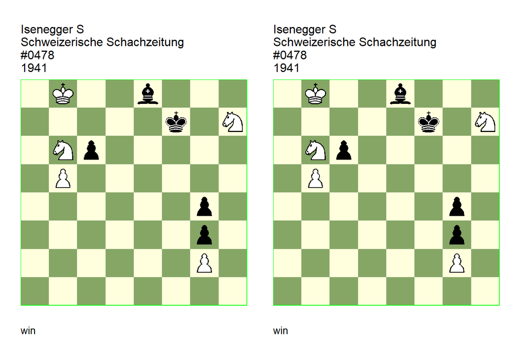

GBR: +0032.23b8f7 (c) U2 FEN: 1K2b3/5k1N/1Np5/1P6/6p1/6p1/6P1/8 w - - 0 1

Schweizerische Schachzeitung=12 Schweizerische Schachzeitung/12. correction: Isenegger=S Schweizerische Schachzeitung=1 1/1943. U2: Neuenschwander=B beatochess 04/11/2025. **1. Nf6! Kxf6** (1… cxb5 main 2. Nxe8! Kxe8 3. Kc7! Ke7 4. Kc6 b4 5. Kd5 Kf6 6. Ke4 Kg5 7. Nc4 b3 8. Nb2 Kh5 9. Kf5 Kh4 10. Kf4 Kh5 11. Kxg3 Kg5 12. Na4 Kf5 13. Kh4 Kf4 14. g3+ Kf3 15. Nb2) **2. Nd7+! Bxd7 3. b6 Be6 4. b7 Bd5 5. Ka7** **cook**s **BN** other winning moves **5… Bxg2 6. b8=Q Bd5 7. Qxg3 Kf5 8. Kb6 Bf3 9. Kc5 Kg5 10. Kd4 Kf5 11. Qe5+ Kg6 12. Ke3 Kf7 13. Kf4 Kg6 14. Qe6+ 1-0**.

GBR: +0032.23b8f7 (s) FEN: 1K2b3/5k1N/1Np5/1P6/6p1/6p1/6P1/8 w - - 0 1

changed solution: Neuenschwander=B beatochess 04/11/2025. **1. Nf6! Kxf6** ( 1… cxb5 2. Nxe8) **2. Nd7+! Bxd7 3. b6 1-0**.

### 2.1.5 Isenegger =0400.11g6g2 (1941). Cooks

Black is winning in various ways.

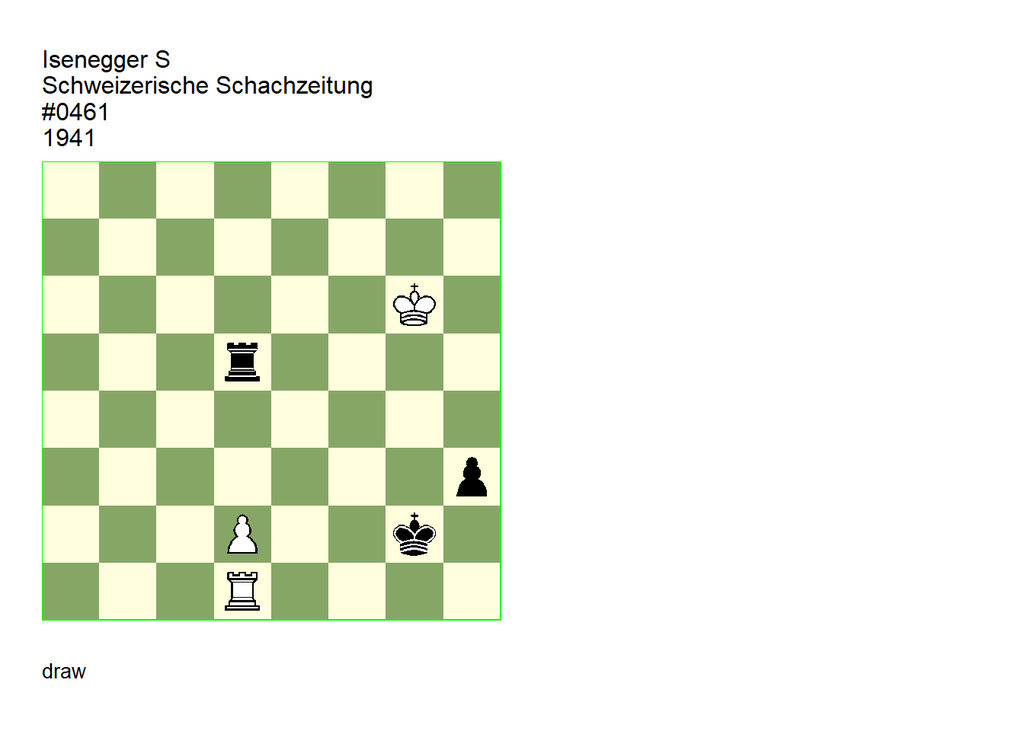

GBR: =0400.11g6g2 U3 FEN: 8/8/6K1/3r4/8/7p/3P2k1/3R4 w - - 0 1

Schweizerische Schachzeitung=8 Schweizerische Schachzeitung/8. U3: Neuenschwander=B beatochess 04/11/2025.. **1. d3!** (1. d4? h2 2. Rd2+ Kg3 3. Rd3+ Kh4! 4. Rd1 Rg5+ 5. Kf6 Rg1) **1… h2 2. Rd2+ Kg3 3. Rd1 Kg4** (3… Re5 **cook** **BN** ) **4. Rh1 Rd6+ 5. Kf7!** (5. Kg7? Kg3 6. Rd1 Kf3! 7. Kf7 Rh6 8. d4 Ke4 9. d5 Ke5 10. Rh1 Kxd5 11. Kg7 Rh3) **5… Rh6** (5… Kg3 **cook** **BN** 6. Rd1 Rh6 7. d4 Kf4) **6. d4 Kf5** (6… Kg3 7. Rd1 Rd6 8. Rd3+ Kg4 9. Rd1 Rh6 10. Rh1) **7. d5 Rh7+ 8. Kg8! Rh3 9. Kg7 Ke5 10. Kg6 Kxd5 11. Kf5 1/2-1/2**.

### 2.1.6 Isenegger =0000.12b5e5 (1941). Cooks or (minor) duals?

For me the clou is the first move. In the play afterwards White can switch the move order, but the way to a draw remains the same. So I would demote Rainer’s cooks to duals or minor duals.

File: Isenegger1941d.pgn

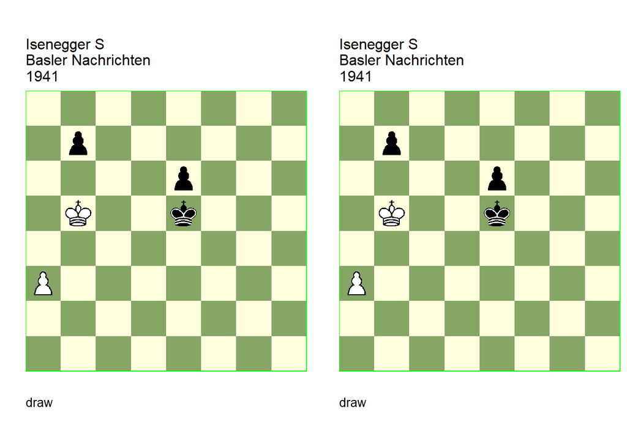

GBR: =0000.12b5e5 (v) U2 FEN: 8/1p6/4p3/1K2k3/8/P7/8/8 w - - 0 1

U2: Staudte=R HHdbIV#20148 5-5-2005. **1. Kc5!** (1. Kb6? Kd6! 2. a4 e5! 3. a5 e4 4. Kxb7 e3 5. a6 e2 6. a7 e1=Q 7. a8=Q Qb4+ 8. Ka6 (8. Kc8 Qc4+ 9. Kb7 Qb5+) 8… Qa4+ 9. Kb7 Qb5+ 10. Ka7 Kc7) **1… Kf5 2. a4** (2. Kb6! **cook** RS ) **2… e5 3. a5** (3. Kb6! **cook** RS ) **3… e4 4. Kb6 e3 5. Kxb7 e2 6. a6 e1=Q 7. a7 1/2-1/2**.

GBR: =0000.12b5e5 (v) (U2) FEN: 8/1p6/4p3/1K2k3/8/P7/8/8 w - - 0 1

U2: Staudte=R HHdbIV#20148 5-5-2005. Comment: Neuenschwander=B beatohess 04/11/2025. **1. Kc5!** (1. Kb6? Kd6! 2. a4 e5! 3. a5 e4 4. Kxb7 e3 5. a6 e2 6. a7 e1=Q 7. a8=Q Qb4+ 8. Ka6 (8. Kc8 Qc4+ 9. Kb7 Qb5+) 8… Qa4+ 9. Kb7 Qb5+ 10. Ka7 Kc7) **1… Kf5 2. a4** (2. Kb6! **cook** RS **dual** **BN** ) **2… e5 3. a5** (3. Kb6! **cook** RS **dual** **BN** ) **3… e4 4. Kb6 e3 5. Kxb7 e2 6. a6 e1=Q 7. a7 1/2-1/2**.

### 2.1.7 Isenegger +0005.10d6a6 (1942). Cooks

White has many first moves that win.

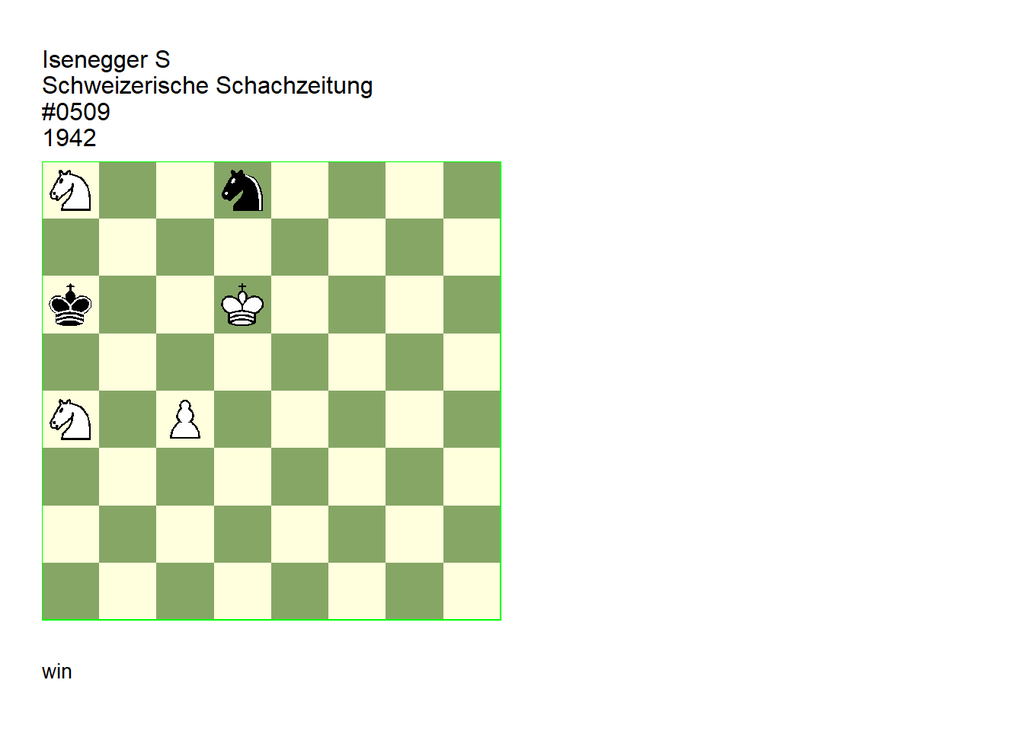

GBR: +0005.10d6a6 U1 FEN: N2n4/8/k2K4/8/N1P5/8/8/8 w - - 0 1

Schweizerische Schachzeitung=12 Schweizerische Schachzeitung/12. U1: Neuenschwander=B beatochess 11/11/2025.. **1. Kd7!** **cook** **BN** many winning moves (TB). **1… Nb7** (1… Nf7 2. Nc5+ Ka7 3. Nd3! Ng5 4. c5 Ne4 5. c6 Nf6+ 6. Ke6! Ne8 7. Ke7) **2. Kc7 Na5** (2… Ka7 3. N8b6 Ka6 (3… Nc5 4. Nc8+) 4. Nc8 Na5 5. Nc5#) **3. Nc5+ Ka7 4. Nb6 Nxc4 5. Nc8+ Ka8 6. Nd7** (6. Na4 or ) **6… Ne3 7. Ndb6# 1-0**.

### 2.1.8 Isenegger +0301.24a2a4 (1942). Cook

**4… Kb4!** cooks the study.

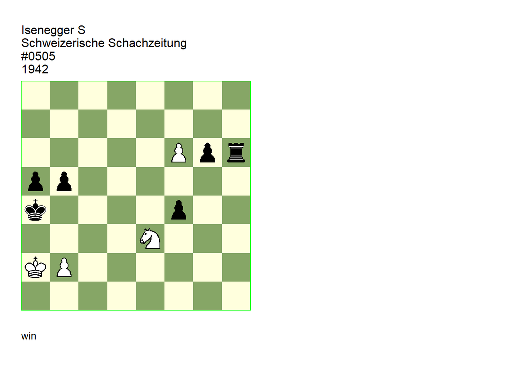

GBR: +0301.24a2a4 U3 FEN: 8/8/5Ppr/pp6/k4p2/4N3/KP6/8 w - - 0 1

Schweizerische Schachzeitung=11 Schweizerische Schachzeitung/11. U3: Neuenschwander=B beatochess 11/11/2025. **1. f7** (1. b3+? Kb4 2. Nd5+ Kc5 3. f7 Rh2+ 4. Kb1 Rh1+ 5. Kc2 Rh2+ 6. Kd3 Rh3+ 7. Ke4 Rh8 8. Nf6 Rf8 9. Nd7+ Kd6 10. Nxf8 Ke7 11. Nxg6+ Kxf7 12. Nxf4 a4!) **1… Rh8 2. b3+ Kb4 3. Nd5+ Kc5 4. Nf6 Rf8** (4… Kb4! **cook** **BN** 5. Ng8 Rh2+ 6. Kb1 Kxb3 -+) **5. Nd7+ Kd6 6. Nxf8 Ke7 7. Nxg6+ Kxf7 8. Nxf4 Ke7 9. Kb2 Kd6 10. Kc3 Kc5 11. Nd3+ Kd5 12. Nf2! Ke5 13. Kd3 Kd5 14. Ne4 1-0**.

### 2.1.9 Isenegger +3721.24d7f5 (1942). Cooks

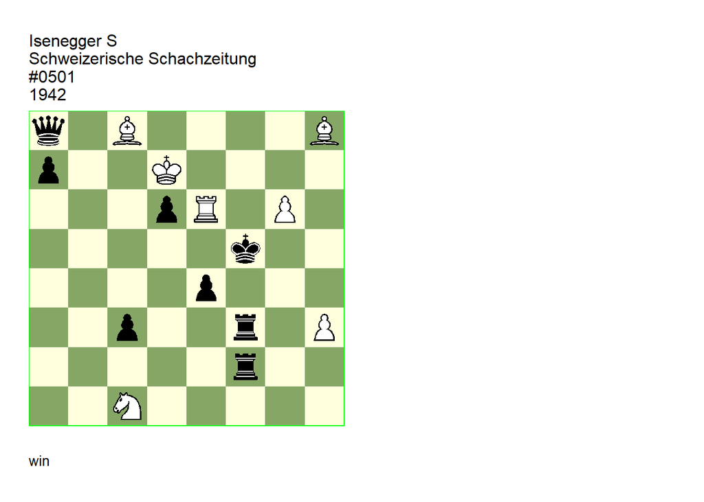

GBR: +3721.24d7f5 U2 U3 FEN: q1B4B/p2K4/3pR1P1/5k2/4p3/2p2r1P/5r2/2N5 w - - 0 1

Schweizerische Schachzeitung=9 Schweizerische Schachzeitung/9. U2 U3 Neuenschwander=B beatochess 11/11/2025 . **1. g7 Rg2 2. Rf6+ Ke5 3. Rxf3 Kd5 4. Rf5+** (4. Rf8 **cook**? **BN** ) **4… Kc4 5. Ba6+ Kb4 6. Rb5+ Ka4 7. Bb7 Qb8!** ( 7… Qg8 8. Bc6 Rxg7+ **cook** **BN** 9. Bxg7 Qxg7+ 10. Kxd6 Qf8+ =) **8. Rb3! Qg8 9. Bc6+ Ka5 10. Rb5+ Ka6 11. Bd5 Rxg7+ 12. Bxg7 Qxg7+ 13. Kc6 Qe5 14. Bc4 Qe8+ 15. Kxd6 Qf8+ 16. Kd5 Qf5+ 17. Kd4 Qf2+ 18. Kxc3 Qe1+ 19. Kc2 1-0**.

### 2.1.10 Isenegger +0031.43e4c4 (1942). Minor dual, wrong date

There is a minor (move order) dual in the second mainline. The date in **HHdbVI** is given as 2015– the study number in **SSZ** suggest 1942 as the correct year.

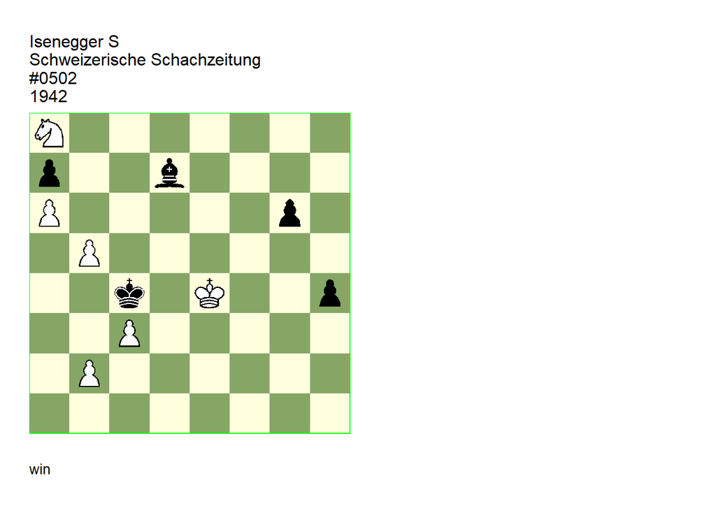

GBR: +0031.43e4c4 (U2) FEN: N7/p2b4/P5p1/1P6/2k1K2p/2P5/1P6/8 w - - 0 1

Schweizerische Schachzeitung=9 Schweizerische Schachzeitung/9. (U2): Neuenschwander=B beatochess 24/11/2025. **1. Nb6+! axb6 2. a7 Kxb5** (2… Bh3 main 3. Kf3 (3. b3+ minor **dual** 3… Kc5 4. Kf3 Be6 5. c4) 3… Be6 4. b3+ Kc5 5. c4) **3. c4+ Kc5 4. b4+ Kd6 5. b5 Bh3 6. Kf3 1-0**.

### 2.1.11 Fischer & Isenegger +1300.02h1b3 (1943). Cook

**3. Kg1!** cooks the study.

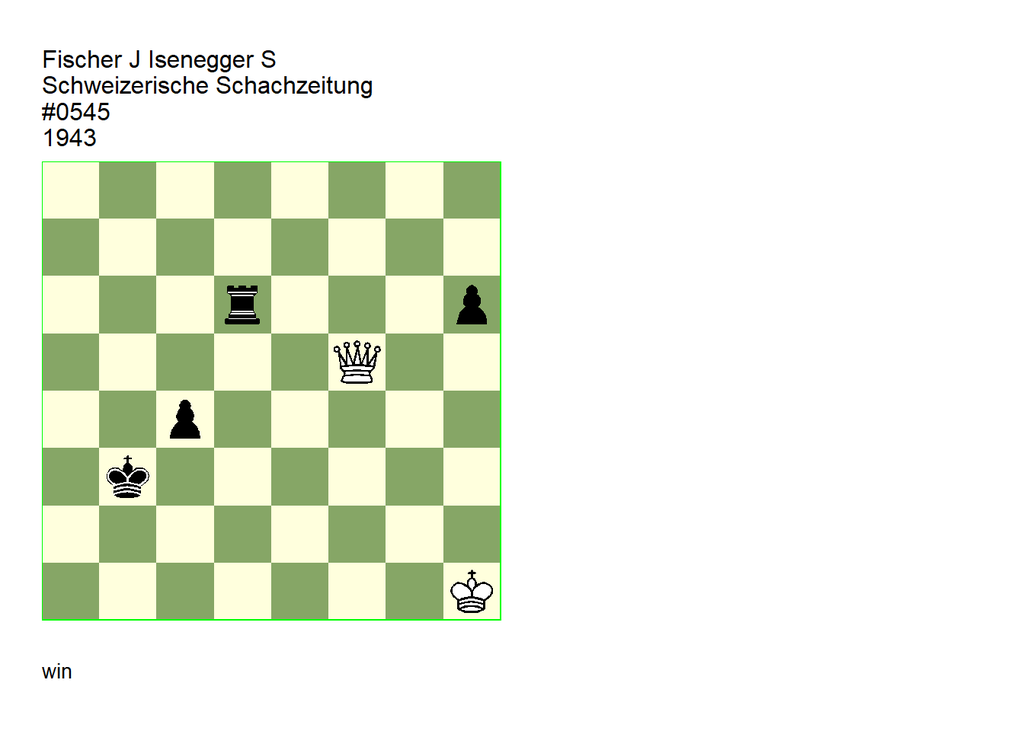

GBR: +1300.02h1b3 U2 FEN: 8/8/3r3p/5Q2/2p5/1k6/8/7K w - - 0 1

Schweizerische Schachzeitung=11 Schweizerische Schachzeitung/11. U2: Neuenschwander=B beatochess 13/11/2025. **1. Qb5+ Kc3 2. Qe5+ Rd4 3. Kg2** (3. Kg1! **cook** **BN** TB ) **3… Kd3 4. Kf3 Rh4** (4… Rd8 5. Qf5+) (4… h5 5. Qe3+) (4… c3 5. Qe2#) (4… Kc3 5. Ke3) **5. Qe2+ 1-0**.

### 2.1.12 Isenegger =0311.21b5d1 (1943). Cook

**1. Bc6!** cooks the study..

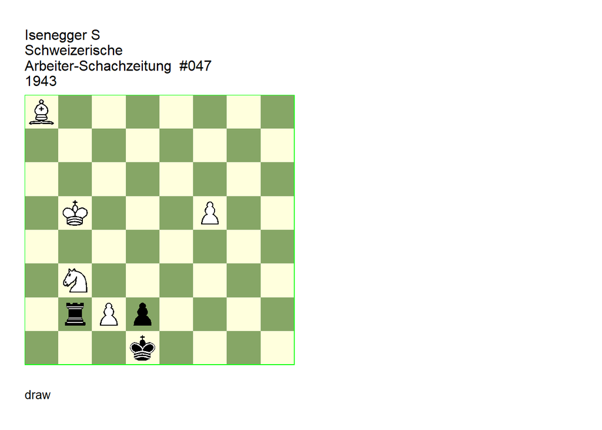

GBR: =0311.21b5d1 U1 FEN: B7/8/8/1K3P2/8/1N6/1rPp4/3k4 w - - 0 1

Schweizerische Arbeiter-Schachzeitung=3 Schweizerische Arbeiter-Schachzeitung/3. U1: Neuenschwander=B beatochess 13/11/2025. **1. Bd5!** (1. Bc6! **cook** **BN** 1… Ke2 (1… Kxc2 2. Kc4 Rxb3? (2… d1=Q 3. Be4+ ) 3. Ba4) 2. Be8) **1… Ke2** (1… Kxc2 main 2. Kb4! d1=Q 3. Be4+ Qd3 4. Bxd3+ Kxd3 5. Ka3) (1… Ke1 2. Bf3) **2. Bf7 1/2-1/2**.

### 2.1.13 Isenegger +0000.11c6e2 (1944). Not cooked (shortened solution)

This is an example of a study where Isenegger gives a mainline that is longer than needed. The point of the study is the first move, the rest is trivial.

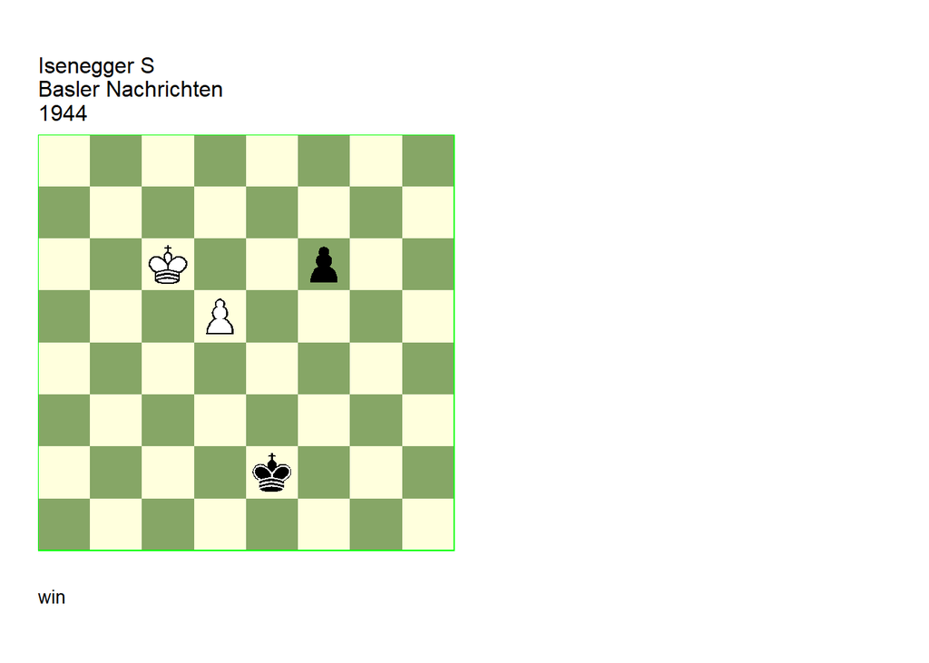

GBR: +0000.11c6e2 (s) FEN: 8/8/2K2p2/3P4/8/8/4k3/8 w - - 0 1

shortened solution: Neuenschwander=B beatochess 15/11/2025. **1. Kd6!** (1. d6? f5 2. d7 f4 3. d8=Q f3) **1-0**.

### 2.1.14 Isenegger +0146.22g5f7 (1944). Cooks

The main problem is the cook **9… Kg7** in the second mainline.

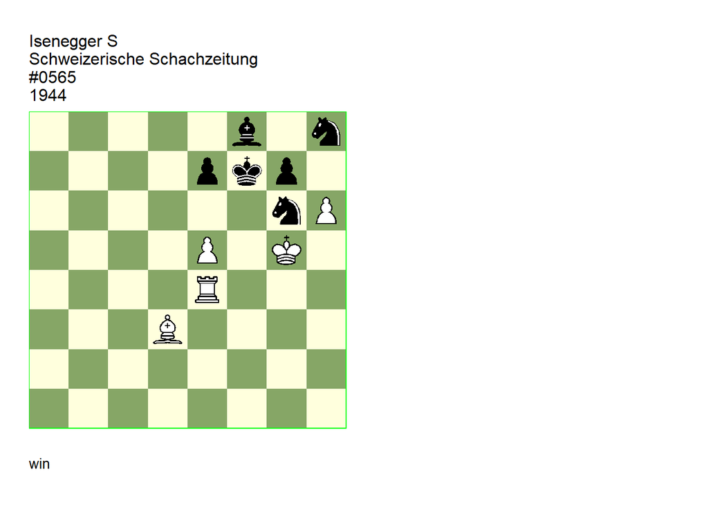

GBR: +0146.22g5f7 U2 U3 FEN: 5b1n/4pkp1/6nP/4P1K1/4R3/3B4/8/8 w - - 0 1

Schweizerische Schachzeitung=2 Schweizerische Schachzeitung/2. U2, U3: Neuenschwander=B 15/11/2025. **1. e6+ Kg8** (1… Ke8 2. Rd4 gxh6+ 3. Kf5 Nh4+ 4. Ke4 Bg7 5. Bb5+ Kf8 6. Rd8#) **2. h7+!** (2. Kh5! **cook** **BN** 2… gxh6 3. Rg4) (2. Rg4! **cook** **BN** 2… gxh6+ 3. Kh5) **2… Kxh7 3. Rh4+ Kg8 4. Rxh8+! Nxh8 5. Bg6 Nf7+** (5… Nxg6 main 6. Kxg6 Kh8 7. Kf7 g5 8. Kxf8 g4 9. Kxe7 g3 (9… Kg7! **cook** **BN** ) 10. Kf7 g2 11. e7 g1=Q 12. e8=Q+ Kh7 13. Qe4+ Kh6 14. Qh4#) **6. Bxf7+ Kh7 7. Bg6+ Kg8 8. Kf5 Kh8 9. Ke5 Kg8 10. Kd5 Kh8 11. Kc6 Kg8 12. Kd7 Kh8 13. Ke8 Kg8 14. Bf7+ Kh7** eg **15. Kxf8 1-0**.

**5. Nc6+** cooks the study.

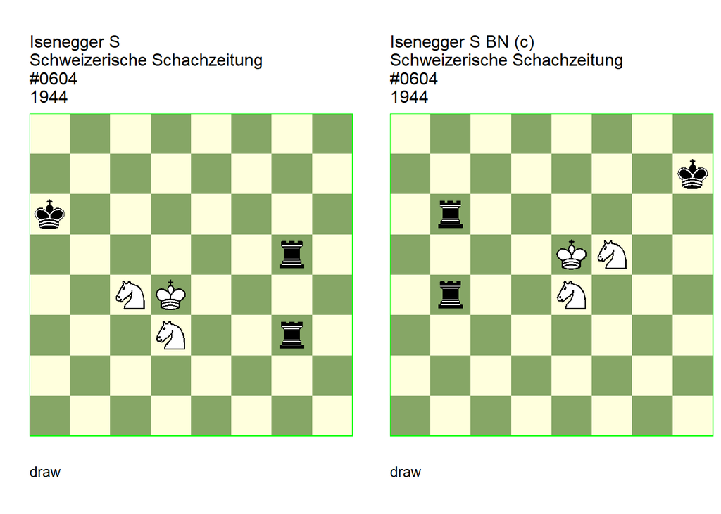

GBR: =0602.00d4a6 U2 FEN: 8/8/k7/6r1/2NK4/3N2r1/8/8 w - - 0 1

Schweizerische Schachzeitung=12 Schweizerische Schachzeitung/12. U2: Neuenschwander=B 15/11/2025. **1. Nc5+ Ka7! 2. Ne4 R3g4 3. Ne5 Rf4 4. Ke3 Rgf5 5. Nd6!** (5. Nc6+! **cook** **BN** ) **5… Rf8 6. Ng6 Rf3+ 7. Ke4 R8f6 8. Ne8 Rf7 9. Nd6! 1/2-1/2**.

GBR: =0602.00d4a6 (c) FEN: 8/7k/1r6/4KN2/1r2N3/8/8/8 w - - 0 1

correction: Neuenschwander=B 15/11/2025. **1. Nf6+ Kh8 2. Nd5 R6b5 3. Nd4 Rc5 4. Kd6 Rbc4 5. Ne3 Rc1 6. Nb3 Rc6+ 7. Kd5 R1c3 8. Nd1 R3c4 9. Ne3 Rc3 10. Nd1 Rc2 11. Ne3 R2c3 12. Nd1 1/2-1/2**.

### 2.1.16 Isenegger =0611.00c1d3 (1944). Cook, correction

**3… Kc3!** cooks the study because Black threatens mate.

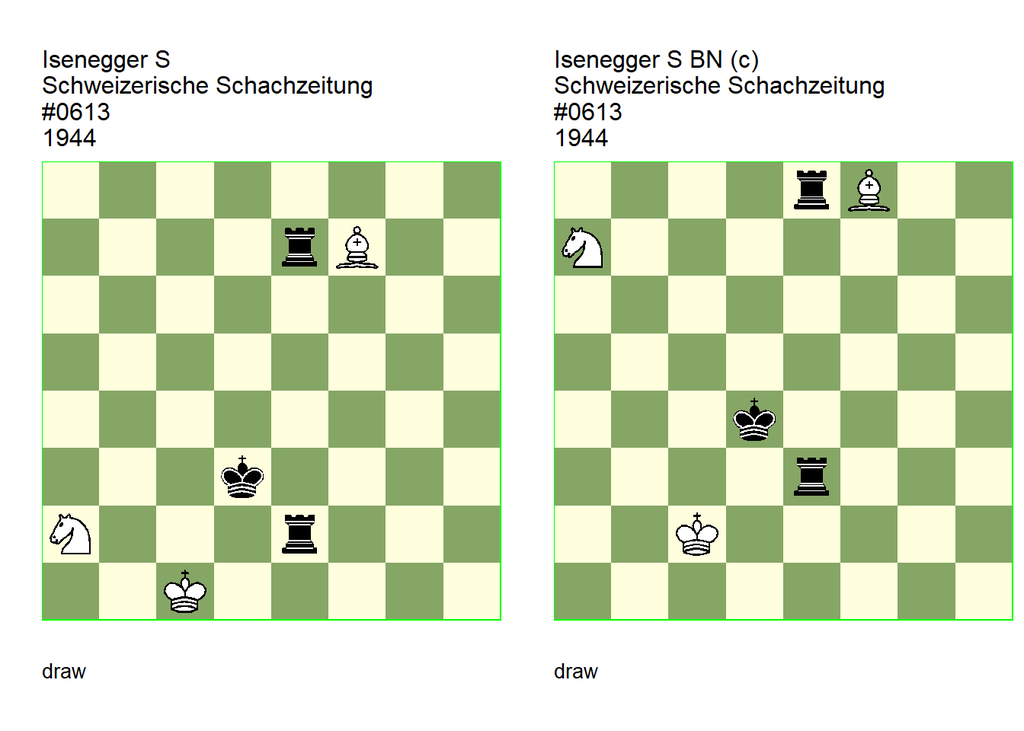

GBR: =0611.00c1d3 U3 FEN: 8/4rB2/8/8/8/3k4/N3r3/2K5 w - - 0 1

Schweizerische Schachzeitung=12 Schweizerische Schachzeitung/12. U3: Neuenschwander=B beatochess 15/11/2025. **1. Nb4+ Ke4 2. Bg6+ Kd4 3. Nc6+ Kc3! -+** **cook** **BN** **1/2-1/2**.

GBR: =0611.00c2d4 (c) FEN: 4rB2/N7/8/8/3k4/4r3/2K5/8 w - - 0 1

correction: Neuenschwander=B beatochess 15/11/2025. **1. Nb5+ Ke5 2. Bg7+ 1/2-1/2**.

### 2.1.17 Isenegger =3230.54g8e8 (1944). Cook

**2. Rg8!** cooks the study.

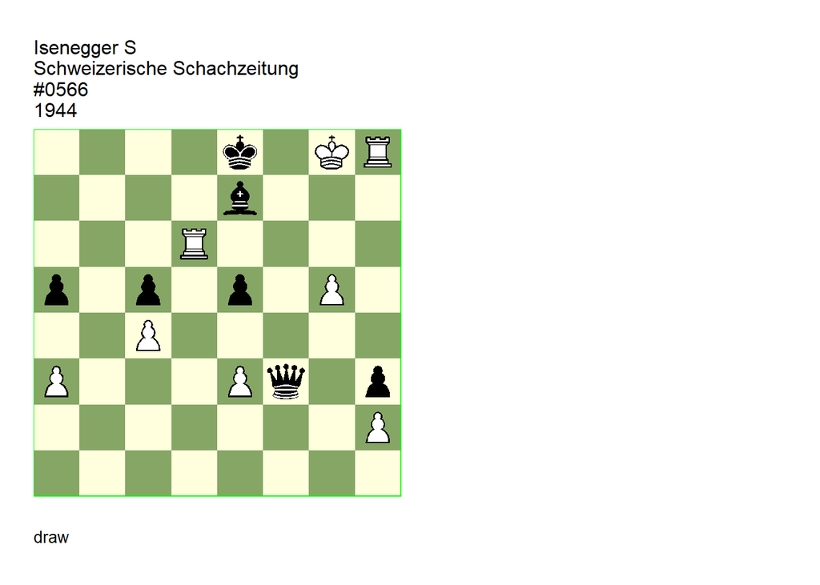

GBR: =3230.54g8e8 U2 FEN: 4k1KR/4b3/3R4/p1p1p1P1/2P5/P3Pq1p/7P/8 w - - 0 1

Schweizerische Schachzeitung=2 Schweizerische Schachzeitung/2. U2: Neuenschwander=B beatochess 16/11/2025. **1. Kh7+ Bf8 2. Rxf8+!** (2. Rg8! **cook** **BN** 2… Ke7 3. Rgg6) **2… Qxf8 3. Rf6 Qe7+ 4. Kg8 e4 5. a4 Qe5 6. Rf8+ Ke7 7. Rf7+ Ke6 8. Rf6+** (8. g6? Qxh2! 9. Rh7 (9. g7 Qg2) 9… Kf6) **8… Qxf6 9. gxf6 Kxf6 10. Kf8 Kf5** eg **11. Ke7 Kg4 12. Kd6 Kf3 13. Kxc5 Kxe3** ( 13… Kg2 14. Kd4) **14. Kb6 1/2-1/2**.

Other rook moves on move 4 work as well of course.

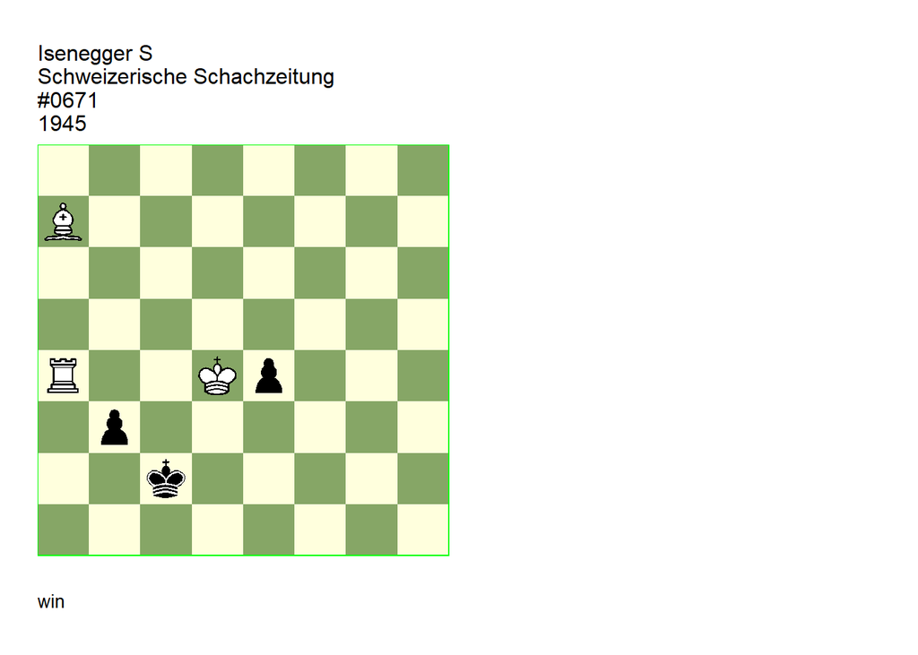

GBR: +0110.02d4c2 (U2) FEN: 8/B7/8/8/R2Kp3/1p6/2k5/8 w - - 0 1

Schweizerische Schachzeitung=12 Schweizerische Schachzeitung/12. (U2): beatochess Neuenschwander=B 16/11/2025. **1. Kc4 b2 2. Ra2 Kc1! 3. Be3+ Kb1 4. Ra5** (4. Kb3?) (4. Ra7 minor **dual**s **BN** , other rook moves… ) **4… Kc2 5. Rd5 b1=Q 6. Rd2+ Kc1 7. Kc3! Qa1+ 8. Kb3 Qb1+ 9. Rb2+ 1-0**.

### 2.1.19 Isenegger =4030.22a6b8 (1945). Cook, correction

The second mainline **2… Kc8** is cooked. The correction has three stalemates (two almost identical ones though), the third one arising after **1… Kc8**, which was not an option due to **2. Kb6** in the original study.

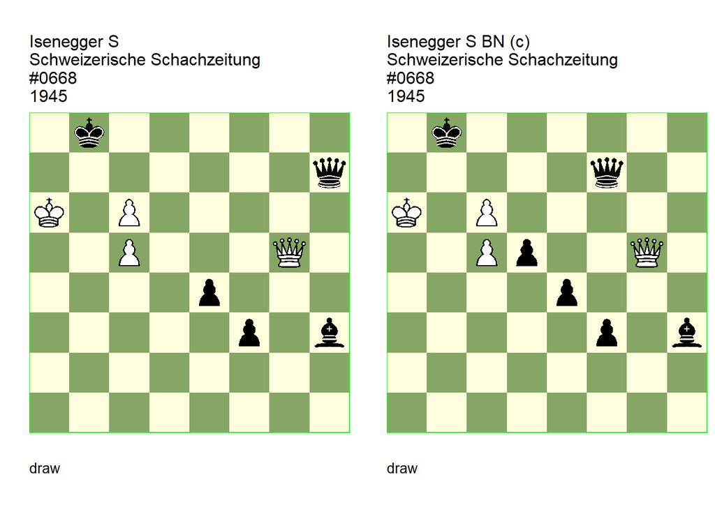

GBR: =4030.22a6b8 U2 FEN: 1k6/7q/K1P5/2P3Q1/4p3/5p1b/8/8 w - - 0 1

Schweizerische Schachzeitung=11 Schweizerische Schachzeitung/11. U2: Neuenschwander=B 16/11/2025. **1. Qe5+ Qc7 2. Qb2+ Ka8** (2… Kc8 main 3. Qh8+ Qd8 4. Qxh3+ Kc7 5. Qh7+ (5. Qh2+ **cook** **BN** ) (5. Kb5 **cook** **BN** ) 5… Kxc6 6. Qb7+! Kxc5 7. Qc7+! Qxc7) **3. Qb7+! Qxb7+ 4. cxb7+ Kb8 5. c6 Bc8 6. c7+ Kxc7 7. Ka7 Bxb7 1/2-1/2**.

GBR: =4030.23a6b8 (c) FEN: 1k6/5q2/K1P5/2Pp2Q1/4p3/5p1b/8/8 w - - 0 1

correction: Neuenschwander=B beatochess 17/11/2025. **1. Qe5+ Qc7** (1… Kc8 main 2. Qh8+ Kc7 3. Qxh3 Kxc6 4. Qh6+ Kxc5 5. Qb6+ Kc4 6. Qc7+ Qxc7) **2. Qb2+ Ka8** (2… Kc8 main 3. Qh8+ Qd8 4. Qxh3+ Kc7 5. Qh7+ Kxc6 6. Qb7+! Kxc5 7. Qc7+! Qxc7) **3. Qb7+! Qxb7+ 4. cxb7+ Kb8 5. c6 Bc8 6. c7+ Kxc7 7. Ka7 Bxb7 1/2-1/2**.

### 2.1.20 Isenegger =0314.01f8d7 (1946). Correction

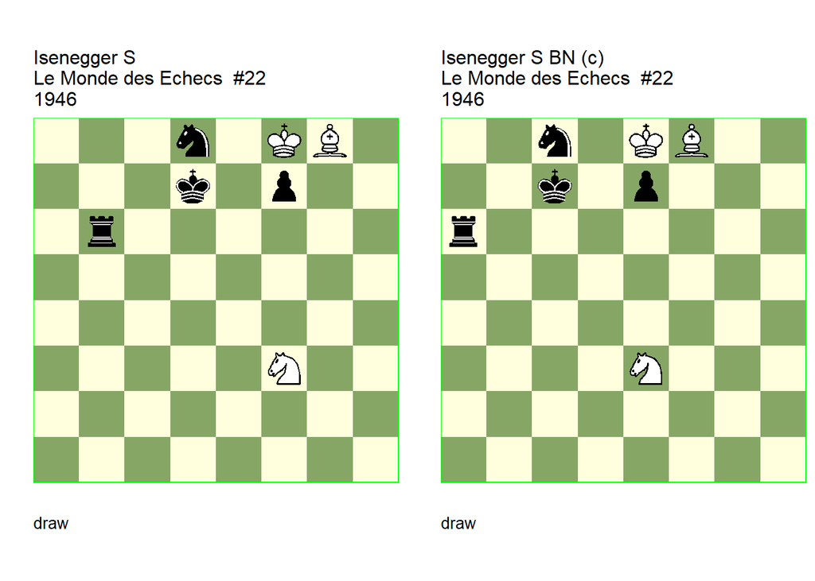

GBR: =0314.01f8d7 U3 FEN: 3n1KB1/3k1p2/1r6/8/8/5N2/8/8 w - - 0 1

Le Monde des Echecs=4 Le Monde des Echecs/6. U3: Nunn=J HHdbIII#46651 31-8-2002 U3: Haworth=G Bleicher=E HHdbIV#22164 1-11-2009. **1. Ne5+** (1. Bxf7? Rf6! 2. Ne5+ (2. Ng5 Nxf7) 2… Kd6 3. Ke8 Kxe5) **1… Ke6 2. Nxf7 Nxf7** (2… Nc6! **cook** JN ) (2… Nb7! **cook** GH/EB ) **3. Kg7!** (3. Bxf7+? Kf6 4. Kg8 Rb8+) **3… Rb7 4. Kg6 1/2-1/2**.

GBR: =0314.01e8c7 (c) FEN: 2n1KB2/2k1p3/r7/8/8/4N3/8/8 w - - 0 1

correction: Neuenschwander=B beatochess 23/11/2025. **1. Nd5+ Kd6 2. Nxe7 Nxe7 3. Kf7! Ra7 4. Kf6 1/2-1/2**.

### 2.1.21 Isenegger =0011.03b3a1 (1946). Comment

The mainline should end after **6. Bf4+**. Otherwise the study is formally cooked.

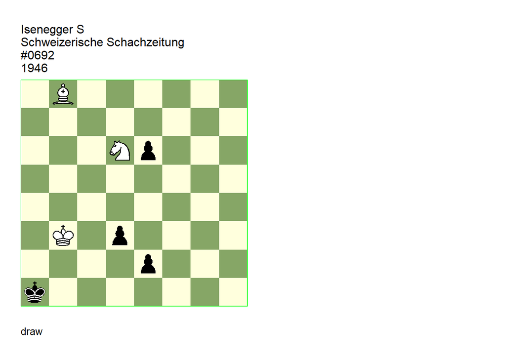

GBR: =0011.03b3a1 (s) FEN: 1B6/8/3Np3/8/8/1K1p4/4p3/k7 w - - 0 1

Schweizerische Schachzeitung=6 Schweizerische Schachzeitung/6. comment: beatochess Neuenschwander=B 23/11/2025. **1. Ne4 e1=Q 2. Be5+ Kb1 3. Nc3+ Kc1 4. Na2+ Kd1 5. Nc3+ Kd2 6. Bf4+** e.g. **6… Qe3 7. Bxe3+** (7. Nb1+!) (7. Ne4+!) **7… Kxe3 8. Kc4 1/2-1/2**.

### 2.1.22 Isenegger +0100.01f7a3 (1946). Comment

The mainline should end after **5. Kb3**. Otherwise the study is formally cooked.

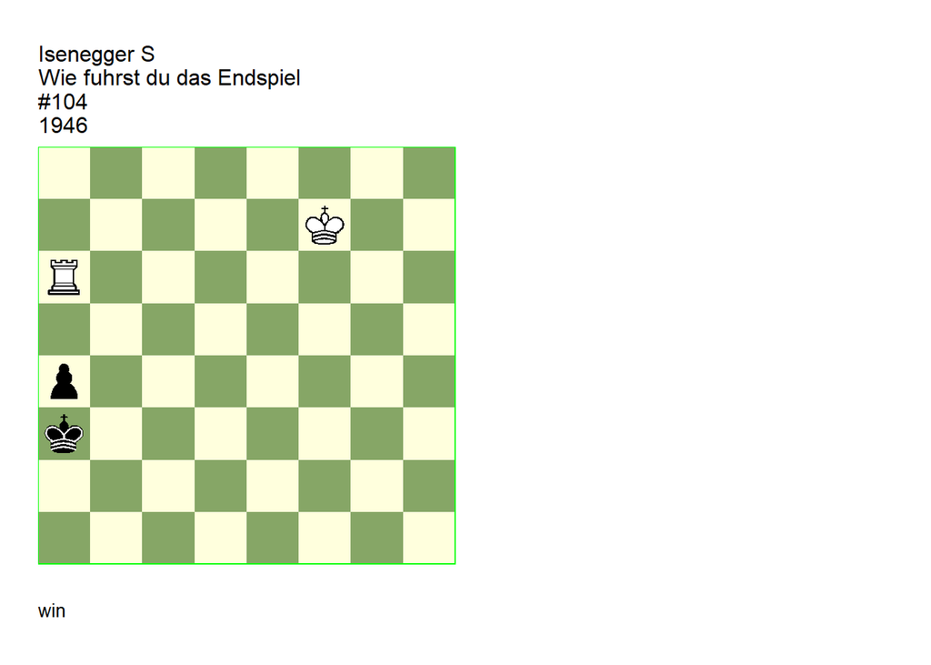

GBR: +0100.01f7a3 (s) FEN: 8/5K2/R7/8/p7/k7/8/8 w - - 0 1

comment: beatochess Neuenschwander=B 23/11/2025. **1. Rb6!** (1. Ke6? Kb3 2. Kd5 a3 3. Kd4 a2 4. Kd3 Kb2 5. Rb6+ Kc1 6. Ra6 Kb2) **1… Ka2 2. Ke6 a3 3. Kd5 Ka1 4. Kc4 a2 5. Kb3 Kb1** e.g. **6. Ka3+** (6. Rh6! a1=N+ 7. Kc3 Ka2 8. Re6 Kb1 9. Re2) **6… Ka1 7. Re6 Kb1 8. Re1+ 1-0**.

### 2.1.23 Isenegger =0331.20d7g6 (1947). Cook, version

**1… Kxh6** cooks the study. That alternative White moves fail in the version can only be understood with tablebase.

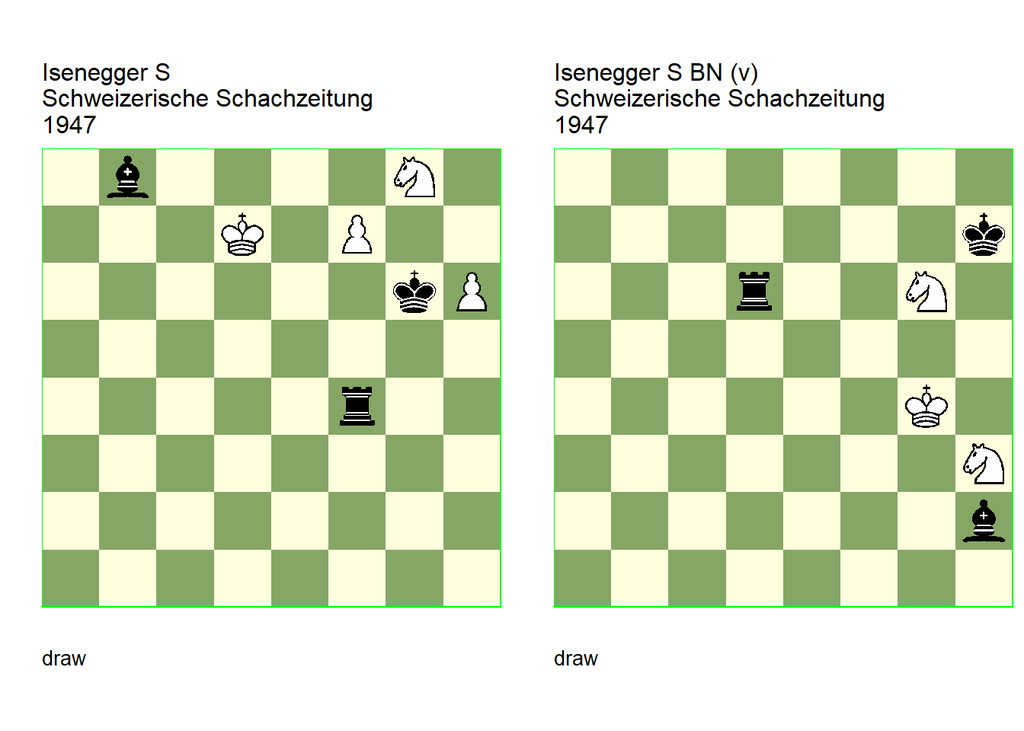

GBR: =0331.20d7g6 U3 FEN: 1b4N1/3K1P2/6kP/8/5r2/8/8/8 w - - 0 1

Schweizerische Schachzeitung=6 Schweizerische Schachzeitung/6. U3: Neuenschwander=B 17/11/2025. **1. Ne7+ Kxf7** (1… Kxh6! **cook** **BN** 2. Nc6 Rxf7+) **2. Nc6 1/2-1/2**.

GBR: =0331.20d7g6 (v) FEN: 8/7k/3r2N1/8/6K1/7N/7b/8 w - - 0 1

version: Neuenschwander=B beatochess 17/11/2025. **1. Ng5+!** (1. Ngf4? DTZ 365 ) (1. Ne7? DTZ 335 ) (1. Nh4? DTZ 297 ) (1. Nhf4? DTZ 379 ) **1… Kxg6** (1… Kg8 2. Ne7+! Kf8 3. Nf3!) (1… Kg7 2. Nf4! Bg1 3. Nfe6+! Kg6 4. Nf4+ (4. Nf8+ or ) 4… Kg7 5. Nfe6+ Kg8 = because the black king cannot take part in the action ) **2. Nf3 1/2-1/2**.

### 2.1.24 Isenegger =0332.10e4e8 (1947). Correction

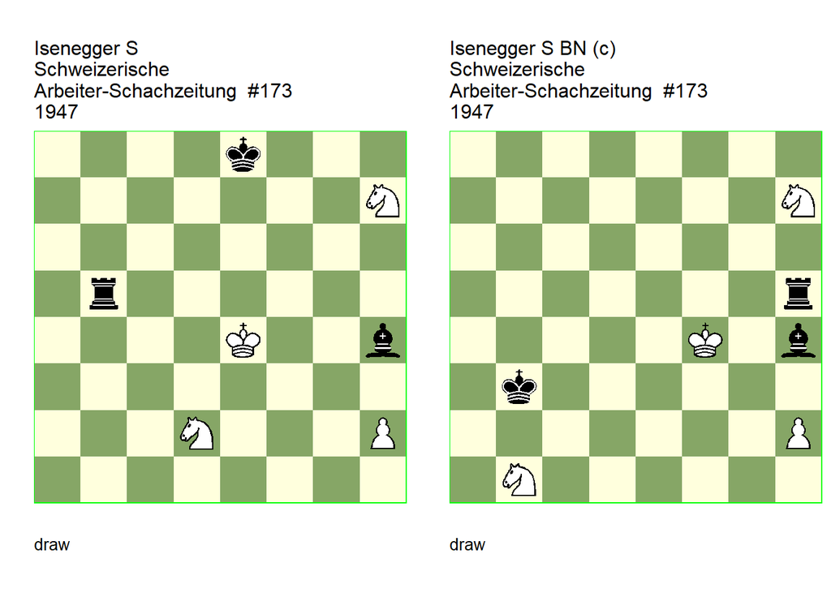

GBR: =0332.10e4e8 U3 FEN: 4k3/7N/8/1r6/4K2b/8/3N3P/8 w - - 0 1

Schweizerische Arbeiter-Schachzeitung=5 Schweizerische Arbeiter-Schachzeitung/5. U3: Ott=R HHdbVI 30-12-2019. **1. Kf4 Rh5** (1… Be7! **cook** RO ) (1… Kf7! **cook** RO ) (1… Rb7! **cook** RO ) **2. Ng5 Rxg5** (2… Bxg5+ main 3. Kg4 Rxh2 4. Nf3 Rg2+ 5. Kh3) **3. Nf3 Rh5 4. Kg4 1/2-1/2**.

GBR: =0332.10f4b3 (c) FEN: 8/7N/8/7r/5K1b/1k6/7P/1N6 w - - 0 1

correction: Neuenschwander=B beatochess 23/11/2025. **1. Nd2+** (1. Ng5? Bxg5+ (1… Rxg5? 2. Nd2+ Kc2 3. Nf3 =) 2. Kg4 Rxh2 3. Kxg5 Rb2 -+) (1. Nf8? Be1 -+) **1… Kc2 2. Ng5! Bxg5+** (2… Rxg5 main 3. Nf3 Rh5 4. Kg4) (2… Kxd2 main 3. Nf3+ Ke2 4. Kg4) **3. Kg4 Rxh2** (3… Rh8 4. Kxg5 Kxd2 5. h4 Ke3 6. h5 =) **4. Nf3 Rg2+ 5. Kh3 1/2-1/2**.

### 2.1.25 Isenegger +0010.23e2e6 (1947). Correction

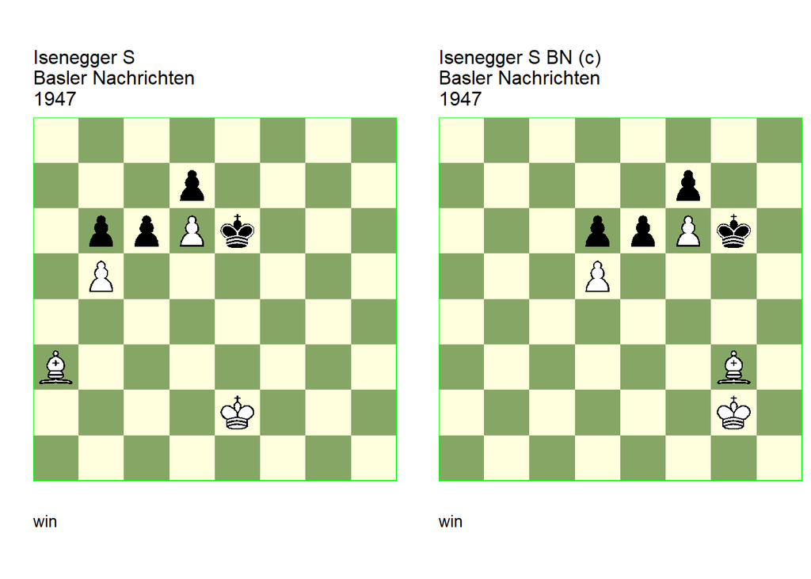

GBR: +0010.23e2e6 U1 FEN: 8/3p4/1ppPk3/1P6/8/B7/4K3/8 w - - 0 1

U1: Garcia=M HHdbV#61309 24-9-2011. **1. Bc5!** (1. Kd3! **cook** MG 1… cxb5 (1… c5 2. Bc1 Kxd6 3. Bf4+ Kd5 4. Kc3 d6 5. Bg5) 2. Ke4 Kf6 3. Kd5 Kf5 4. Bb4 Kf4 5. Bd2+) **1… bxc5** (1… cxb5 main 2. Ba3! Kd5 3. Kd3 Ke5 4. Ke3 Kd5 5. Kf4 Kc4 6. Ke5) **2. b6 Kxd6 3. Kd3 c4+ 4. Kxc4 c5 5. Kb5 c4 6. Ka6 1-0**.

GBR: +0010.23g2g6 (c) FEN: 8/5p2/3ppPk1/3P4/8/6B1/6K1/8 w - - 0 1

correction: Neuenschwander=B beatochess 23/11/2025. **1. Be5!** (1. Bh4? exd5 2. Kf3 Kf5 =) **1… dxe5** / **2. d6 Kxf6 3. Kf3 e4+ 4. Kxe4 e5 5. Kd5 e4 6. Kc6 1-0**.

### 2.1.26 Isenegger +0000.21e5g5 (1948). Cook, shortened solution

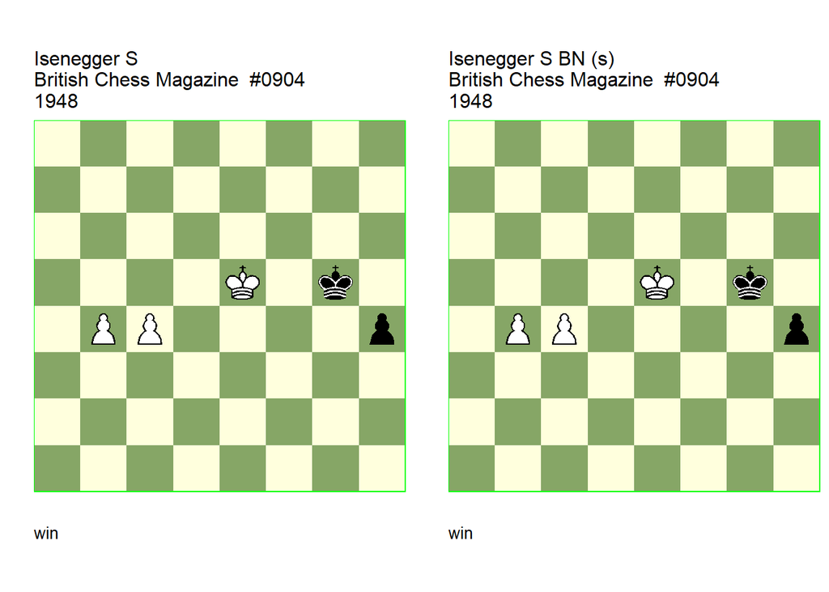

GBR: +0000.21e5g5 U2 FEN: 8/8/8/4K1k1/1PP4p/8/8/8 w - - 0 1

British Chess Magazine/12. U2: Neuenschwander=B beatochess 18/11/2025. **1. Ke4 Kg4 2. Ke3 Kg3 3. b5 h3 4. b6 h2 5. b7 h1=Q 6. b8=Q+ Kg4 7. Qf4+ Kh5 8. Qf3+** The fastest, but the queen ending is also won **cook**s **BN** **8… Qxf3+ 9. Kxf3 Kg5 10. Ke4 Kf6 11. Kd5 Ke7 12. Kc6 1-0**.

GBR: +0000.21e5g5 (s) FEN: 8/8/8/4K1k1/1PP4p/8/8/8 w - - 0 1

shortened solution: Neuenschwander=B beatochess 18/11/2025. **1. Ke4 Kg4 2. Ke3 Kg3 3. b5 h3 4. b6 h2 5. b7 h1=Q 6. b8=Q+ Kg4 7. Qf4+ 1-0**.

### 2.1.27 Isenegger =0311.23c4a7 (1948). Cook

**6. Nc2!** cooks the correction.

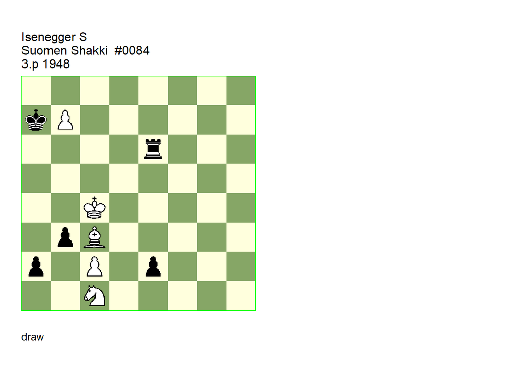

GBR: =0311.23c4a7 (c) U2 FEN: 8/kP6/4r3/8/2K5/1pB5/p1P1p3/2N5 w - - 0 1

Suomen Shakki=4 Suomen Shakki/6. correction: Garcia=M Estudios Artisticos de Ajedrez - IV-69 2012. U2: Neuenschwander=B 18/11/2025. **1. Nxe2** (1. Bd4+? Rb6 ) **1… Rc6+** (1… Rxe2 2. Bd4+ Kxb7 3. Kxb3) **2. Kxb3 Rxc3+ 3. Kb2! Rxc2+ 4. Ka1 Kxb7** (4… Rxe2 5. b8=Q+ Kxb8) **5. Nd4 Rh2** (5… Rc4 6. Nb3 Rc2 7. Nd4) **6. Nb5!** (6. Nc2! **cook** **BN** ) **6… Rc2 7. Nd4 1/2-1/2**.

### 2.1.28 Isenegger +4043.04d5a4 (1948). Correction

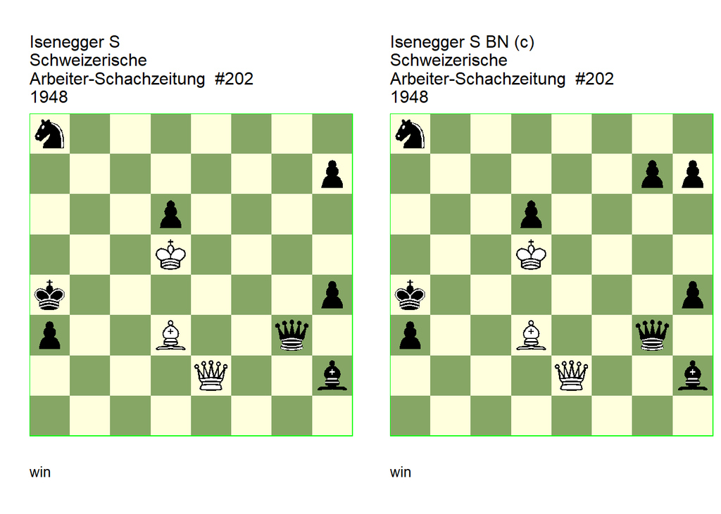

GBR: +4043.04d5a4 U2 FEN: n7/7p/3p4/3K4/k6p/p2B2q1/4Q2b/8 w - - 0 1

Schweizerische Arbeiter-Schachzeitung=1-2 Schweizerische Arbeiter-Schachzeitung/1-2. U2: Garcia=M HHdbV#60948 24-9-2011. **1. Qe8+! Kb3 2. Qb5+ Kc3 3. Qc4+ Kd2 4. Qc2+ Ke3 5. Qe2+ Kf4 6. Qe4+ Kg5 7. Qf5+ Kh6 8. Qxh7+ Kg5 9. Qg6+** (9. Qf5+! **cook** MG 9… Kh6 10. Qf6+ Kh5 11. Be2+) **9… Kf4 10. Qf5+ Ke3 11. Qe4+ Kd2 12. Qe2+ Kc3 13. Qc2+ Kb4 14. Qc4+ Ka5 15. Qb5# 1-0**.

GBR: +4043.05d5a4 (c) FEN: n7/6pp/3p4/3K4/k6p/p2B2q1/4Q2b/8 w - - 0 1

correction: Neuenschwander=B beatochess 23/11/2025 **1. Qe8+ Kb3 2. Qb5+ Kc3 3. Qc4+ Kd2 4. Qc2+ Ke3 5. Qe2+ Kf4 6. Qe4+ Kg5 7. Qf5+ Kh6 8. Qxh7+ Kg5 9. Qg6+ Kf4 10. Qf5+ Ke3 11. Qe4+ Kd2 12. Qe2+ Kc3 13. Qc2+ Kb4 14. Qc4+ Ka5 15. Qb5# 1-0**.

### 2.1.29 Isenegger =0033.20g1a8 (1948). Correction

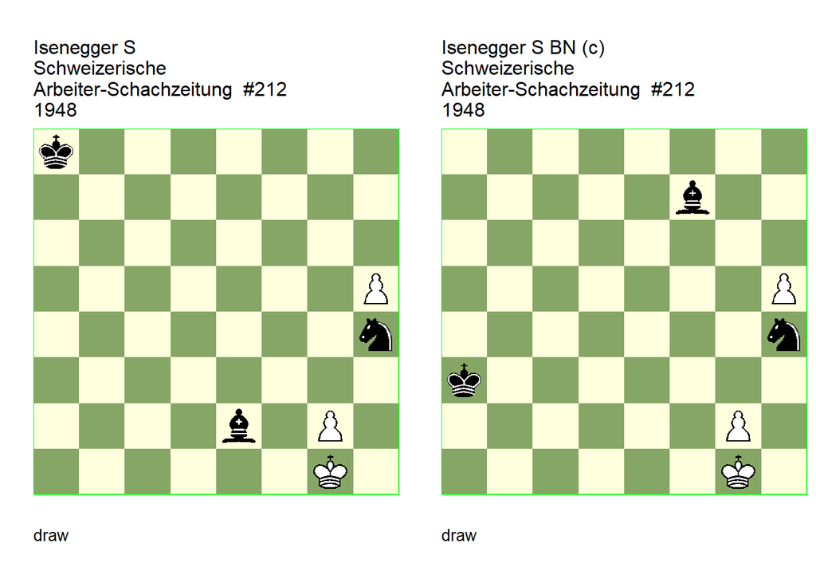

GBR: =0033.20g1a8 U3 FEN: k7/8/8/7P/7n/8/4b1P1/6K1 w - - 0 1

Schweizerische Arbeiter-Schachzeitung=3-4 Schweizerische Arbeiter-Schachzeitung/3-4. U3: Konoval=Y HHdbVI 8-10-2019. **1. Kh2!** (1. h6? Bd3) **1… Bxh5** (1… Nf5 2. Kh3 Kb7 (2… Ng7! **cook** YK 3. h6 Ne6 4. h7 Ng5+ 5. Kh4 Nxh7) 3. g4 Ne7 4. Kh4 Kc6 5. h6) **2. Kh3 Ng6 3. g4 Nf4+ 4. Kg3 Ne2+ 5. Kf3 Nd4+ 6. Ke4! 1/2-1/2**.

GBR: =0033.20g1a3 (c) FEN: 8/5b2/8/7P/7n/k7/6P1/6K1 w - - 0 1

correction: Neuenschwander=B beatochess 23/11/2025. **1. Kh2** (1. Kf2? Bxh5) (1. g4? Nf3+ 2. Kf2 Ng5 3. Kg3 Kb4 4. Kf4 (4. Kh4 Ne4 5. g5 Be6 6. g6 Bf5) 4… Nh7 5. Kf5 Kc5 6. g5 Kd6 7. g6 Be6+ 8. Kf4 Nf8) **1… Bxh5** (1… Kb4 2. Kh3 Nf5 3. Kg4 =) **2. Kh3 Ng6 3. g4 Nf4+ 4. Kg3 Ne2+ 5. Kf3 Nd4+ 6. Ke4 1/2-1/2**.

### 2.1.30 Isenegger =0314.00g4b7 (1948). Correction

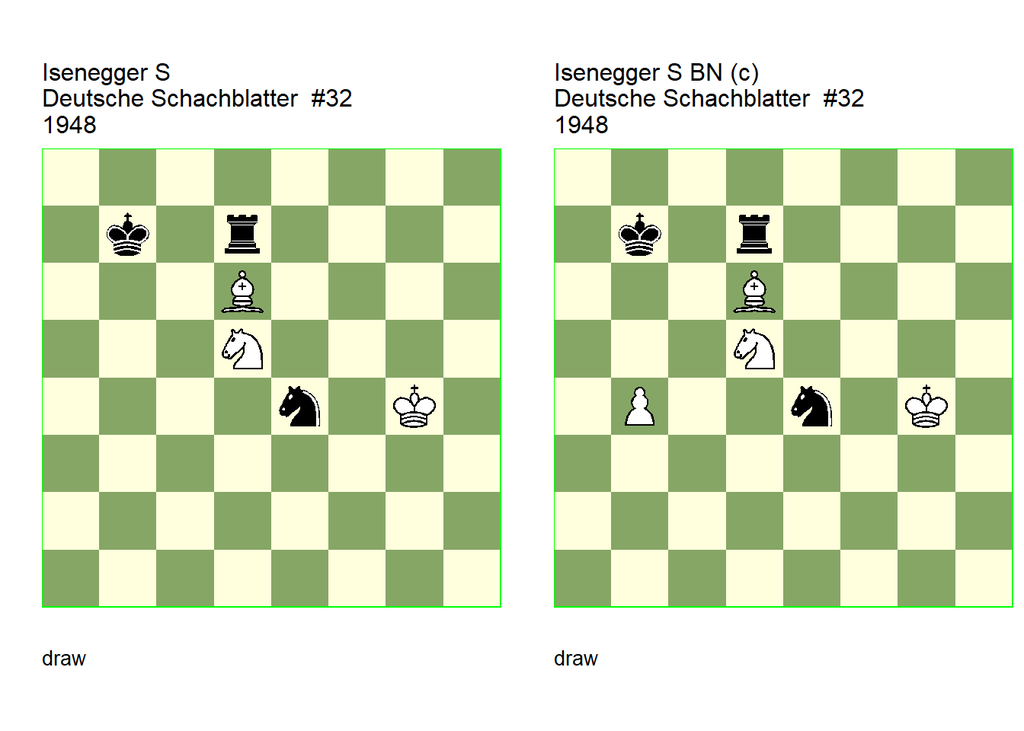

GBR: =0314.00g4b7 U2 FEN: 8/1k1r4/3B4/3N4/4n1K1/8/8/8 w - - 0 1

Deutsche Schachblatter=3. U2: (HHdbII#20659 2001). **1. Kf5 Nxd6+ 2. Ke6 Rd8** ( 2… Kc6 main 3. Ne7+ (3. Nb4+! **cook** ) 3… Kc7 4. Nd5+ Kd8 5. Nf6 Rf7 6. Nd5 Rd7 7. Nf6) **3. Ke7 Kc8** (3… Nf7 4. Nf6!) **4. Nb6+ Kc7 5. Nd5+ Kc8 6. Nb6+ 1/2-1/2**.

GBR: =0314.10g4b7 (c) FEN: 8/1k1r4/3B4/3N4/1P2n1K1/8/8/8 w - - 0 1

correction: Neuenschwander=B beatochess 23/11/2025. **1. Kf5 Nxd6+ 2. Ke6 Rd8** ( 2… Kc6 main 3. Ne7+ Kc7 4. Nd5+ Kd8 5. Nf6) **3. Ke7 Kc8** (3… Nf7 4. Nf6) **4. Nb6+ Kc7 5. Nd5+ Kc8 6. Nb6+ 1/2-1/2**.

### 2.1.31 Isenegger +0000.66e3e7 (1949). Cook, correction

**1. Kd3!** cooks the study.

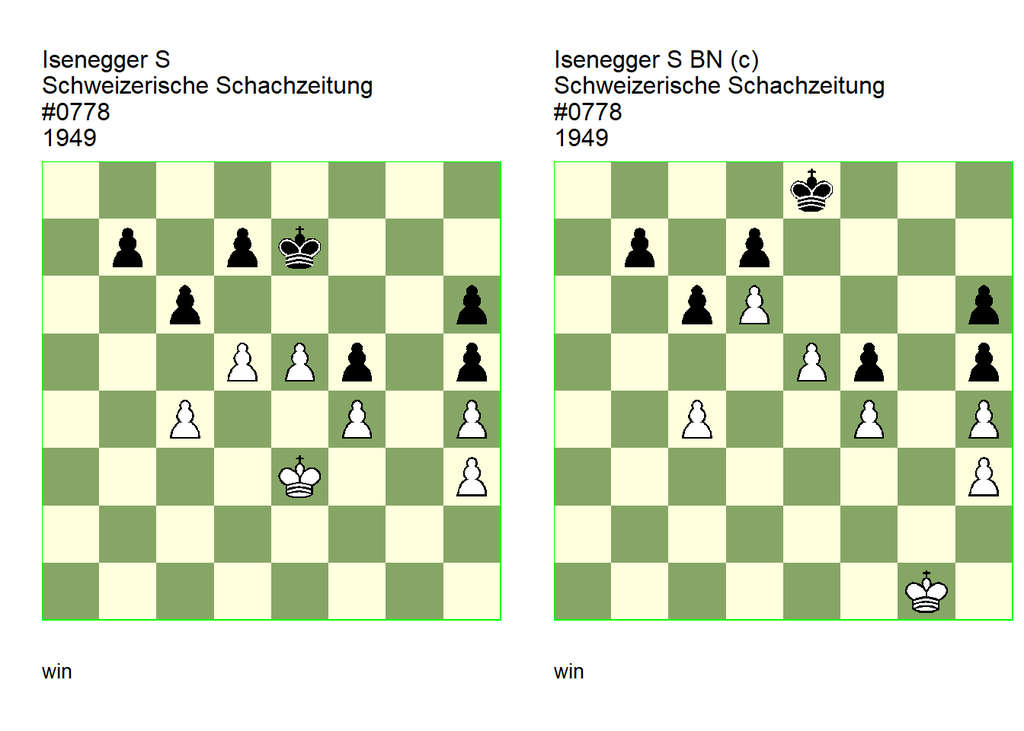

GBR: +0000.66e3e7 (c) U1 FEN: 8/1p1pk3/2p4p/3PPp1p/2P2P1P/4K2P/8/8 w - - 0 1

Schweizerische Schachzeitung=1 Schweizerische Schachzeitung/1. correction: Isenegger=S Schweizerische Schachzeitung=3 3/1949. U1: Neuenschwander=B beatochess 18/11/2025. **1. d6+** (1. Kd3! **cook** **BN** 1… b6 2. Kd4 Kd8 3. e6 dxe6 4. dxc6 Kc7 5. Ke5 Kxc6 6. Kxe6 Kc5 7. Kxf5 Kxc4 8. Ke5 b5 9. f5 b4 10. f6 b3 11. f7 b2 12. f8=Q b1=Q 13. Qc8+ Kb3 14. Qb7+ Kc2 15. Qxb1+) **1… Ke6 2. c5! Kd5 3. e6! Kxe6 4. Kd4 Kf7 5. Kc3! Ke8 6. Kc4! Kd8 7. Kd4 Ke8 8. Ke5 Kf7 9. Kxf5 Kg7 10. Ke5 Kg6 11. f5+ Kf7 12. Kd4 Kf6 13. Kc4 Kxf5 14. Kb4 Kf4 15. Ka5 Kg3 16. Kb6 Kxh4 17. Kc7! Kxh3 18. Kxd7 1-0**.

GBR: +0000.66g1e8 (c) FEN: 4k3/1p1p4/2pP3p/4Pp1p/2P2P1P/7P/8/6K1 w - - 0 1

correction: Neuenschwander=B beatochess 18/11/2025. **1. c5 Kf7 2. Kf2 Ke6 3. Ke3 Kd5 4. e6! Kxe6 5. Kd4 Kf7 6. Kc3! Ke8 7. Kc4! Kd8 8. Kd4 Ke8 9. Ke5 Kf7 10. Kxf5 Kg7 11. Ke5 Kg6 12. f5+ Kf7 13. Kd4 Kf6 14. Kc4 Kxf5 15. Kb4 Kf4 16. Ka5 Kg3 17. Kb6 Kxh4 18. Kc7! Kxh3 19. Kxd7 1-0**.

### 2.1.32 Isenegger +4013.12f1h2 (1949). Cook

**3. Kf2!** cooks the study.

File: Isenegger1949b.pgn

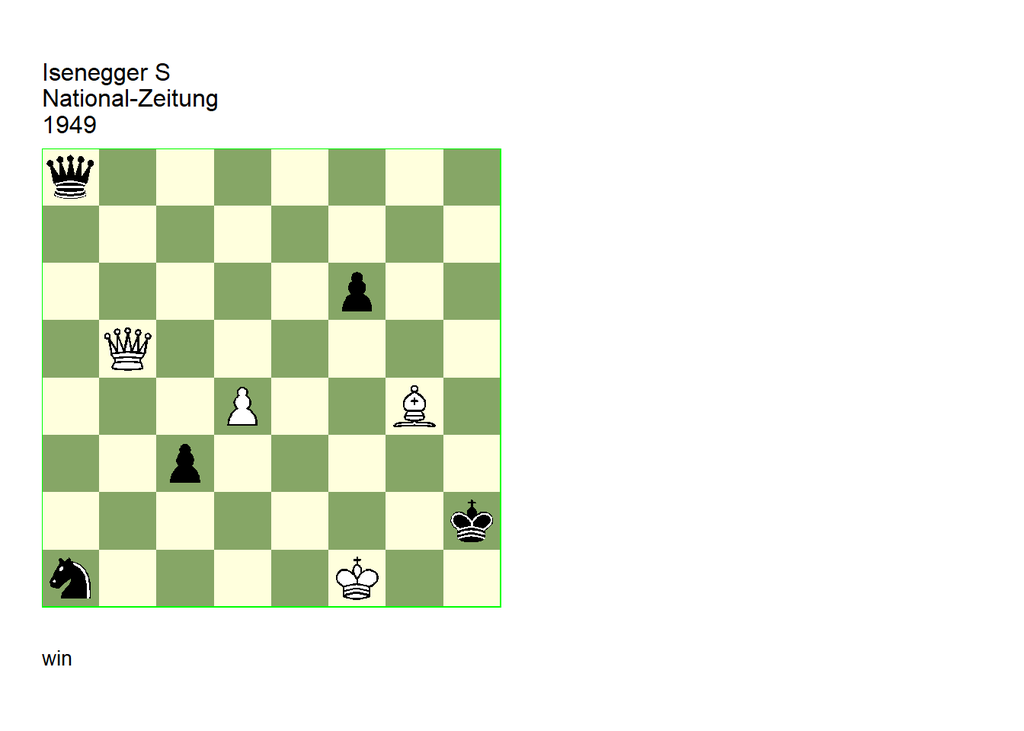

GBR: +4013.12f1h2 U2 FEN: q7/8/5p2/1Q6/3P2B1/2p5/7k/n4K2 w - - 0 1

U2: beatochess Neuenschwander=B 18/11/2025. **1. Qh5+ Kg3 2. Qh3+ Kf4 3. Qh4!** (3. Kf2! **cook** **BN** 3… Qd8 4. Bd7) **3… Qa3** (3… Qa5 main 4. Bf5+ Kxf5 5. Qh5+ Ke4 6. Qxa5) (3… Qa7 main 4. Bh5+! Ke3! 5. Qf2+ Kd3 ( 5… Ke4 6. Qf3+ Kxd4 7. Qf2+) 6. Qe2+ Kxd4 7. Qf2+ Ke5 8. Qxa7) (3… Qd8 main 4. Bh5+) (3… Qe4 main 4. Bd7+ Ke3 5. Qf2+ Kd3 6. Bb5#) (3… Nb3 4. Be2+ Ke3 5. Qf2+) **4. Bd7+** (4. Bc8+! **cook** **BN** 4… Ke3 5. Qf2+ Kd3 6. Ba6+) **4… Ke3 5. Qf2+ Kd3 6. Bb5+ Ke4 7. Bc6+ Kd3 8. Qe2+ Kxd4 9. Qe4+ Kc5 10. Qe7+ Kxc6 11. Qxa3 1-0**.

### 2.1.33 Isenegger =0043.11c7h2 (1950). Cook

**8. Kh4!** cooks the study.

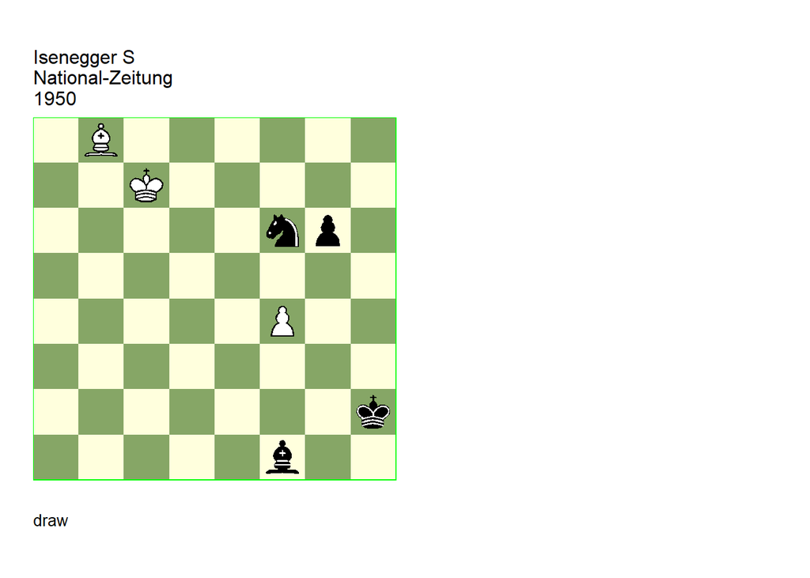

GBR: =0043.11c7h2 U2 FEN: 1B6/2K5/5np1/8/5P2/8/7k/5b2 w - - 0 1

U2: Neuenschwander=B beatochesss 18/11/2025. **1. f5!** (1. Kd8? Kg2) (1. Kc6? Kg2) (1. Kd6? Ne4+ 2. Ke5 (2. Ke6 Ng3 3. Kf6 Bd3) 2… Ng3) **1… gxf5** (1… g5 2. Kd8+ Kh3 3. Ke7 Nh5 4. f6 Bc4 5. f7 Bxf7 6. Kxf7 Nf4 7. Kf6) **2. Kd6 f4 3. Ke6 Nh5 4. Kf5 Kg3 5. Kg5!** (5. Bc7? Bc4!) **5… Be2 6. Bc7** (6. Bd6 or ) (6. Be5? Kf3!) **6… Bg4! 7. Bb8** (7. Be5? Kf3 8. Bb8 Ng7 9. Kf6 Ne6!) **7… Kf3 8. Be5!** (8. Kh4! **cook** **BN** 8… Ng7 9. Bxf4 Kxf4) **8… Ng3** (8… Ke4 9. Bxf4) **9. Bxf4! Ne4+ 10. Kh4 Kxf4 1/2-1/2**.

### 2.1.34 Isenegger +0463.24e5b6 (1951). Cooks

**3… Bxd6+!** and **3… Bb8!** cook the study.

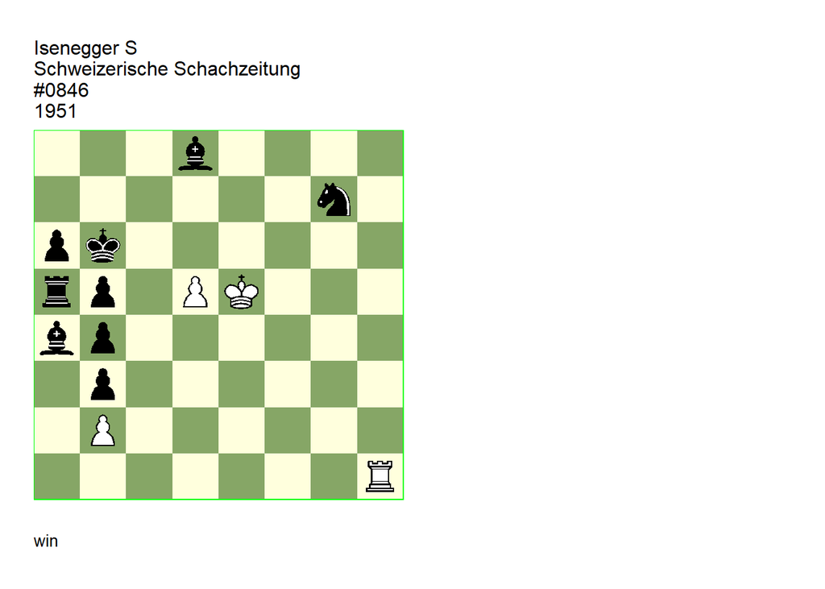

GBR: +0463.24e5b6 U3 FEN: 3b4/6n1/pk6/rp1PK3/bp6/1p6/1P6/7R w - - 0 1

Schweizerische Schachzeitung=6 Schweizerische Schachzeitung/6. U3: Neuenschwander=B beatochess 18/11/2025. **1. Rh6+ Kb7 2. Rh7 Bc7+ 3. d6 Ne8** ( 3… Bxd6+! **cook** **BN** 4. Kxd6 Kb6 5. Rxg7) (3… Bb8! **cook** **BN** 4. Rxg7+ Kc6 5. Rg6 Kc5) **4. Rxc7+!** (4. dxc7? Nxc7 5. Kd6 Kb6! 6. Rxc7) **4… Nxc7 5. d7 Ne6 6. Kxe6 1-0**.

### 2.1.35 Isenegger +0134.01a6e8 (1952). Cooks

At move 6 White has various winning moves.

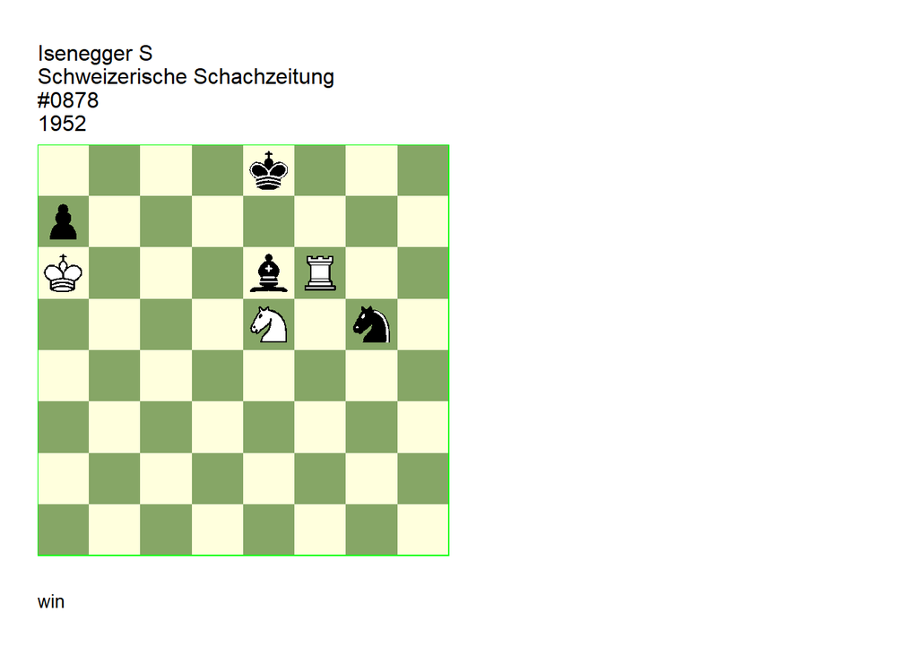

GBR: +0134.01a6e8 U2 FEN: 4k3/p7/K3bR2/4N1n1/8/8/8/8 w - - 0 1

Schweizerische Schachzeitung=11 Schweizerische Schachzeitung/11. U2: Neuenschwander=B beatochess 18/11/2025. **1. Rg6 Bc8+ 2. Kxa7 Nf7** (2… Ne6 main 3. Rg8+ Nf8 4. Ng6 Kf7 5. Rxf8+ Kxg6 6. Rxc8) **3. Rg8+ Ke7 4. Nc6+!** ( 4. Nxf7? Be6) **4… Kd7 5. Kb6 Nd6 6. Rd8+** ( **cook**s **BN** 6. Kc5 /Rg6/Rh8 ) **6… Ke6 7. Kc7 1-0**.

### 2.1.36 Isenegger =0000.11d8d5 (1953). Correction

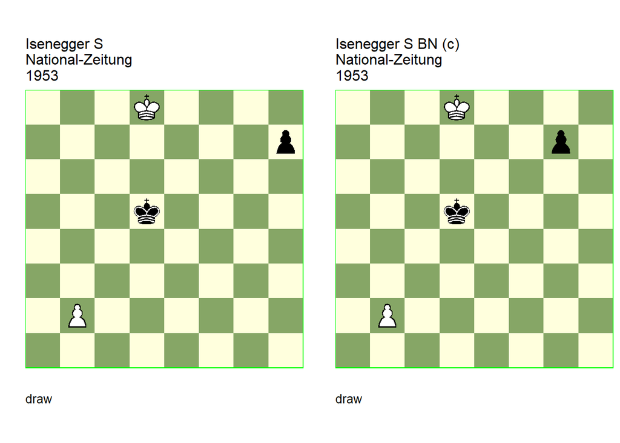

GBR: =0000.11d8d5 U3 FEN: 3K4/7p/8/3k4/8/8/1P6/8 w - - 0 1

U3: Conrady=H HHdbIII#42429 15-3-2001. **1. Kc7** (1. b4? Kc6) **1… h5** (1… Kc5 2. b4+ Kxb4 3. Kd6) **2. b4 Kc4 3. Kc6 Kxb4** (3… h4! **cook** HC 4. b5 h3 5. b6 h2 6. b7 h1=Q+) **4. Kd5 1/2-1/2**.

GBR: =0000.11d8d5 (c) FEN: 3K4/6p1/8/3k4/8/8/1P6/8 w - - 0 1

correction: Neuenschwander=B 23/11/2025. **1. Kc7 g5 2. b4 Kc4 3. Kc6 Kxb4 4. Kd5 1/2-1/2**.

### 2.1.37 Isenegger =0341.21h4h8 (1954). Cooks

**1… Kxg8** and **4… Rg7** are winning for Black.

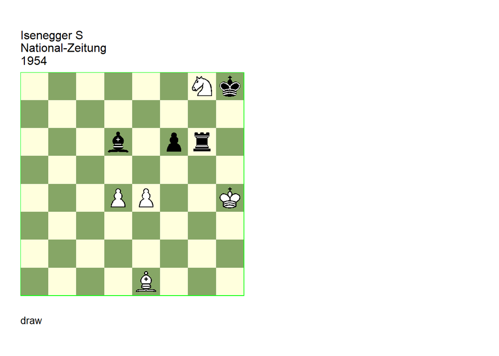

GBR: =0341.21h4h8 U3 FEN: 6Nk/8/3b1pr1/8/3PP2K/8/8/4B3 w - - 0 1

U3: Neuenschwander=B beatochess 18/11/2025. **1. e5! fxe5** (1… Kxg8 **cook** **BN** ) **2. dxe5 Bxe5 3. Ne7 Bf6+ 4. Kh5 Rg5+** (4… Rg7! **cook** **BN** TB DTZ 30 ) **5. Kh6 Bxe7 6. Bc3+ Kg8 7. Bf6 Bxf6 1/2-1/2**.

### 2.1.38 Isenegger =0314.00c6a8 (1954). Correction

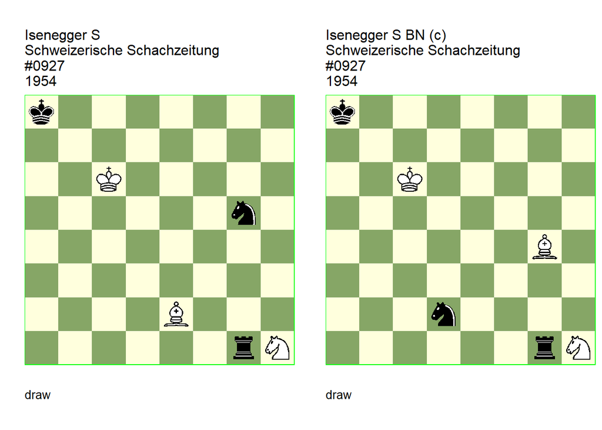

GBR: =0314.00c6a8 U3 FEN: k7/8/2K5/6n1/8/8/4B3/6rN w - - 0 1

Schweizerische Schachzeitung=9 Schweizerische Schachzeitung/9. U3: Nunn=J HHdbIII#41659 31-8-2002. **1. Nf2 Rg2** (1… Rc1+! **cook** JN 2. Kd5 Rc2) **2. Ne4! Nxe4 3. Bf3 Rg6+** (3… Rc2+ main 4. Kb5! Rc5+ 5. Kb4 Re5 6. Kc4 Kb8 7. Kd4) **4. Kd7! Rd6+ 5. Ke7 Rd4 6. Ke6 Ka7 7. Ke5 1/2-1/2**.

GBR: =0314.00c6a8 (c) FEN: k7/8/2K5/8/6B1/8/3n4/6rN w - - 0 1

### 2.1.39 Isenegger =0400.01a7f3 (1954). Correction

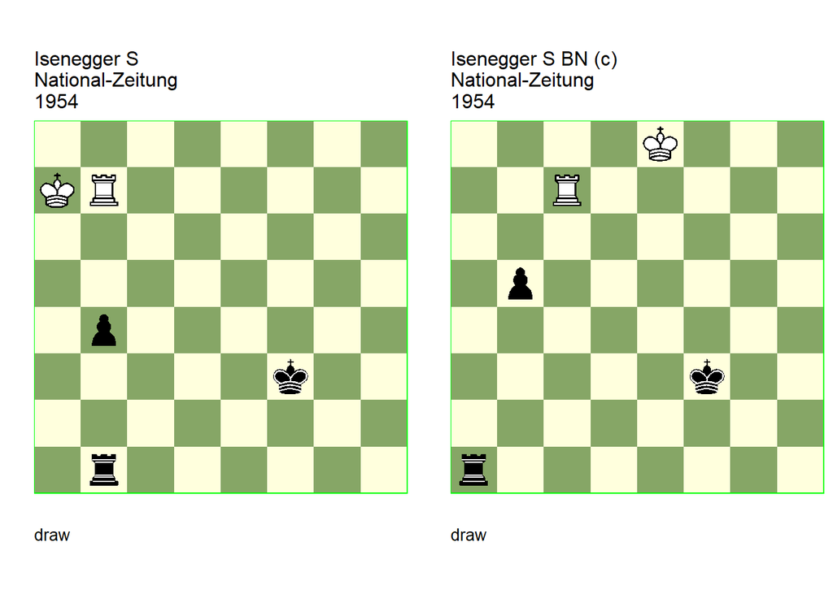

GBR: =0400.01a7f3 U1 FEN: 8/KR6/8/8/1p6/5k2/8/1r6 w - - 0 1

U1: Nunn=J Secrets of Rook Endings#228 1992. **1. Kb6!** (1. Ka6! **cook** JN 1… b3 2. Rb5! Ke3 3. Ka5! Kd3 4. Kb4! Kc2 5. Rh5) (1. Rh7! **cook** JN 1… b3 2. Kb6 Ke3 3. Kb5 Rf1 4. Rh3+ Rf3 5. Rh2! Kd3 6. Kb4) **1… b3** ( 1… Ke4 main 2. Kb5! (2. Kc5? Rc1+) 2… b3 3. Kb4!) **2. Kc5! b2** ( 2… Ke4 3. Kb4!) **3. Rb3+! Ke2 4. Kb6!** (4. Kb5? Kd1! (4… Kd2? 5. Kb4) (4… Ke1? 5. Kb6! Kd2 6. Rb5! Kc3 7. Rc5+ Kd3 8. Rb5 Kd4 9. Rb3! ) 5. Kb4 (5. Rb4 Kd2 6. Rd4+ Ke3 7. Rb4 Kd3!) 5… Kd2!) (4. Kb4? Kd2) **4… Kd2** (4… Kd1 5. Rb5!) **5. Rb5! 1/2-1/2**.

GBR: =0400.01e8f3 (c) FEN: 4K3/2R5/8/1p6/8/5k2/8/r7 w - - 0 1

correction: Neuenschwander=B 18/11/2025. **1. Rb7 Rb1 2. Kd7 b4** (2… Ke4 3. Kc6 b4 4. Kc5 =) **3. Kc6** (3. Kd6? Ke4 4. Kc5 Rc1+ -+) **3… b3** (3… Ke4 4. Kb5 Kd4 5. Rh7 =) **4. Kc5! b2 5. Rb3+! Ke2 6. Kb6! Kd2 7. Rb5! Kc3 8. Rc5+ Kb3 9. Rb5+ 1/2-1/2**.

### 2.1.40 Isenegger +0104.44f6b7 (1955). Correction

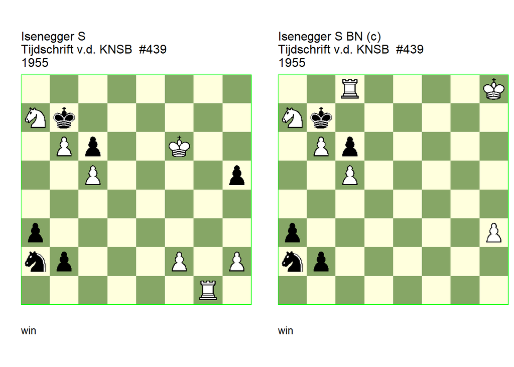

GBR: +0104.44f6b7 U1 FEN: 8/Nk6/1Pp2K2/2P4p/8/p7/np3P1P/6R1 w - - 0 1

Tijdschrift v.d. KNSB/12. U1: Van, der, Heijden=H HHdbV#56176 15-1-2014. **1. Rg7+** (1. Nb5! **cook** HH 1… cxb5 2. Rg7+ Kc6 3. b7 b1=Q 4. b8=Q) **1… Ka6! 2. Nb5! b1=Q 3. Nxa3 Qa1+ 4. Kg6 Ka5** (4… Qg1+ 5. Kh7 Qxg7+ 6. Kxg7) **5. Ra7+ Kb4 6. Nc2+ 1-0**.

GBR: +0104.33h8b7 (c) FEN: 2R4K/Nk6/1Pp5/2P5/8/p6P/np6/8 w - - 0 1

correction: Neuenschwander=B beatochess 18/11/2025. **1. Rc7+ Ka6 2. Nb5!** (2. Nxc6 b1=Q 3. b7 (3. Nd4 Ka5 4. b7 Ka6) 3… Qxb7 4. Rxb7 Kxb7 =) **2… b1=Q 3. Nxa3 Qa1+** (3… Qb2+ 4. Kh7 Qxa3 5. Ra7+) **4. Kh7 Ka5 5. Ra7+** (5. b7 Qc3 6. b8=Q Qxh3+ 7. Kg8 Qg3+ 8. Kf8 Qf4+ 9. Ke8 Qe5+ 10. Kf7 Qf4+ =) **5… Kb4 6. Nc2+ 1-0**.

### 2.1.41 Isenegger =0331.31c8g8 (1955). Cook, correction

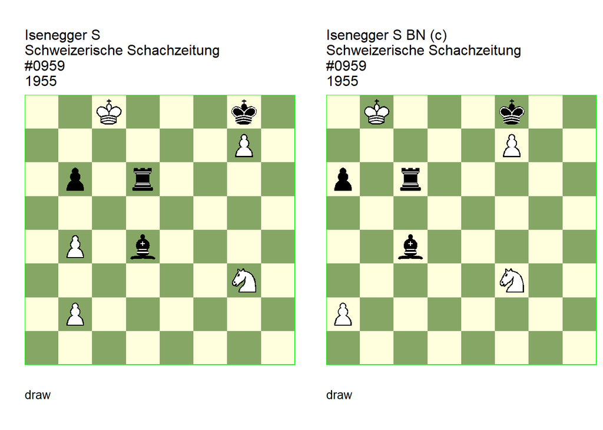

GBR: =0331.31c8g8 U2 FEN: 2K3k1/6P1/1p1r4/8/1P1b4/6N1/1P6/8 w - - 0 1

Schweizerische Schachzeitung=12 Schweizerische Schachzeitung/12. U2: Neuenschwander=B beatochess 18/11/2025. **1. Nf5 Rc6+ 2. Kb7! Rc4 3. b3** (3. Ne7+ **dual** **BN** 3… Kxg7 4. b3 etc. ) **3… Rxb4 4. Ne7+ Kxg7 5. Nc6 Rxb3 6. Nxd4 Rb4** (6… Rb1 7. Ka6) **7. Nc6** (7. Nc2 **cook** **BN** ) **7… Rb1 8. Ka6** (8. Ne5 **cook** **BN** ) **8… b5 9. Ka5 1/2-1/2**.

GBR: =0331.21b8f8 (c) FEN: 1K3k2/5P2/p1r5/8/2b5/5N2/P7/8 w - - 0 1

correction: Neuenschwander=B beatochess 18/11/2025. **1. Ne5 Rb6+ 2. Ka7 Rb4 3. a3** (3. Nd7+? Kxf7 4. a3 Rb5) **3… Ra4 4. Nd7+ Kxf7 5. Nb6 Rxa3 6. Nxc4 Ra4** ( 6… Ra1 7. Kb6 Ke6 8. Na5 Kd5 leads to the mainline ) **7. Nd6+ Ke6 8. Nb7 Kd5 9. Kb6 Ra1 10. Na5 Ra2 11. Nb7 Kc4 12. Na5+ Kb4 13. Nc6+ 1/2-1/2**.

### 2.1.42 Isenegger +3140.42g8h5 (1955). Cook

**11. f3!** appears winning as well.

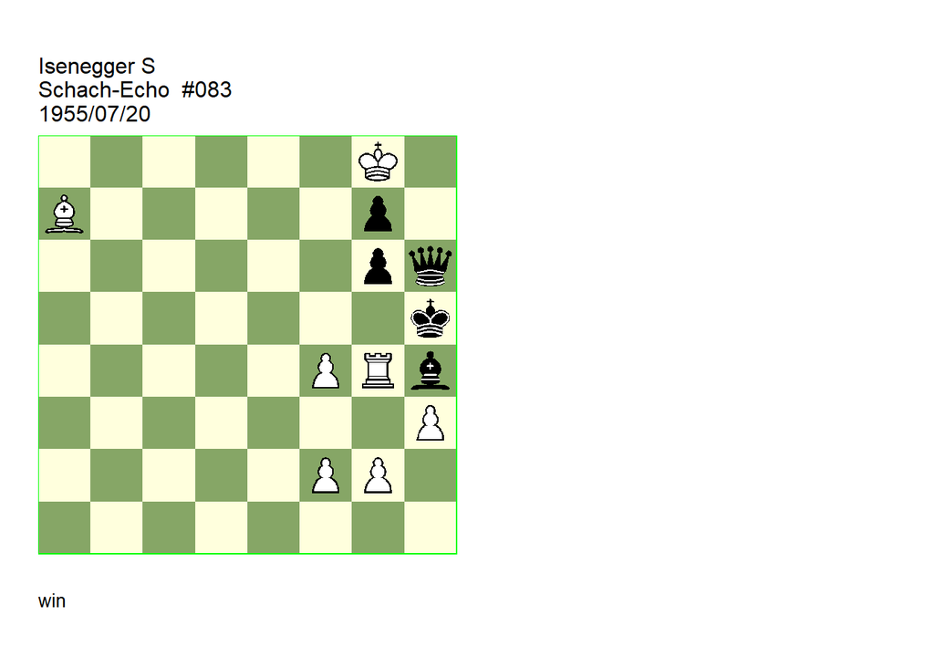

GBR: +3140.42g8h5 U2 FEN: 6K1/B5p1/6pq/7k/5PRb/7P/5PP1/8 w - - 0 1

Schach-Echo=14. U2: Neuenschwander=B beatochess 18/11/2025. **1. g3! g5!** ( 1… Bd8 2. Rh4+! Bxh4 3. g4#) **2. Rxh4+! gxh4 3. g4+ Kg6 4. f5+ Kf6 5. Be3!** (5. Bd4+? Ke7 6. Bxg7 Qf4) **5… g5 6. Bd4+ Ke7 7. Bg7! Qc6 8. f6+ Kd6** ( 8… Kd7 9. f7 Qe6 10. Bf6 Qxf6 11. f8=Q Qb6 12. Qf5+ Kc7 13. f4) **9. f7 Qc4** ( 9… Qd5 10. Bf6) **10. Bf6 Qe6 11. Kg7** (11. f3! **cook** **BN** ) **11… Qd7 12. Kg6 Qc8 13. Kxg5 1-0**.

### 2.1.43 Isenegger +3101.54a7f8 (1956). Cook, correction

**1. Rxc7!** and **1. Rd8+!** cook the study.

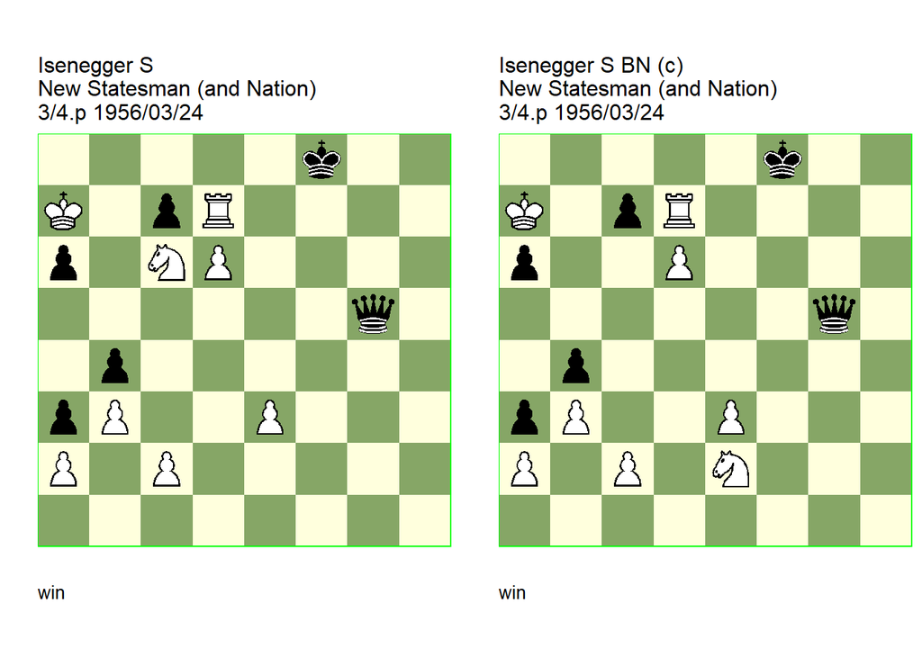

GBR: +3101.54a7f8 U1 FEN: 5k2/K1pR4/p1NP4/6q1/1p6/pP2P3/P1P5/8 w - - 0 1

New Statesman (and Nation)=332. U1: Neuenschwander=B beatochess 18/11/2025 . **1. Nd4** (1. dxc7? Qc5+) (1. Rxc7? Qc5+) (1. Rxc7! **cook** **BN** 1… Qc5+ 2. Kb7 Qxd6 3. e4 +/-) (1. Rd8+! **cook** **BN** 1… Kf7 2. d7) **1… Qc5+ 2. Kb8** (2. Kb7 or ) **2… Qb6+ 3. Ka8! cxd6** (3… a5 4. Ne6+ Kg8 5. Rd8+ Kf7 6. Nxc7 Qxe3 7. d7) (3… c5 4. Ne6+ Kg8 5. Rd8+ Kf7 6. Nc7 c4 7. e4 Qc6+ 8. Kb8 Qxe4 9. d7) **4. Rb7! Qa5 5. Rb5! axb5+ 6. Kb7 Kf7** (6… Qd8 7. Ne6+) **7. Nc6 1-0**.

GBR: +3101.54a7f8 (c) FEN: 5k2/K1pR4/p2P4/6q1/1p6/pP2P3/P1P1N3/8 w - - 0 1

correction: Neuenschwander=B beatochess 18/11/2025. **1. Nd4 Qc5+ 2. Kb7** (2. Ka8? Qd5+ 3. Kb8 cxd6) **2… Qb6+ 3. Ka8 cxd6 4. Rb7 Qa5 5. Rb5! axb5+ 6. Kb7 1-0**.

### 2.1.44 Isenegger +0134.00h1f3 (1959). Cook

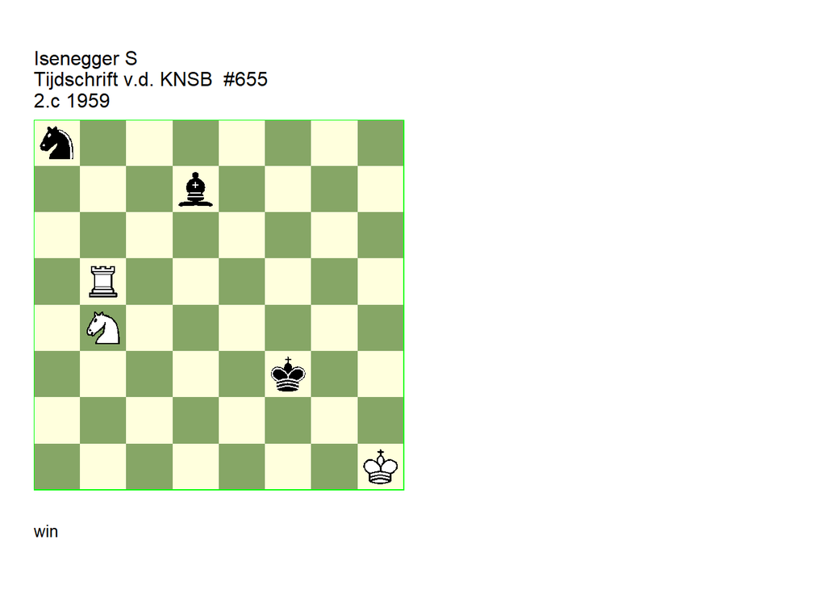

GBR: +0134.00h1f3 U2 FEN: n7/3b4/8/1R6/1N6/5k2/8/7K w - - 0 1

Tijdschrift v.d. KNSB/6. U2: Neuenschwander=B beatochess 18/11/2025. **1. Rb8 Nc7 2. Rf8+! Kg3 3. Rf7 Nd5 4. Nxd5** (4. Rg7+ **cook** **BN** 4… Kh4 (4… Kf2 5. Nd3+ Ke3 6. Rxd7) 5. Rxd7) **4… Bc6 5. Rf5 Kg4 6. Re5 1-0**.

### 2.1.45 Isenegger =0060.41g6g8 (1965). Cook

**7. Kf6!** cooks the study.

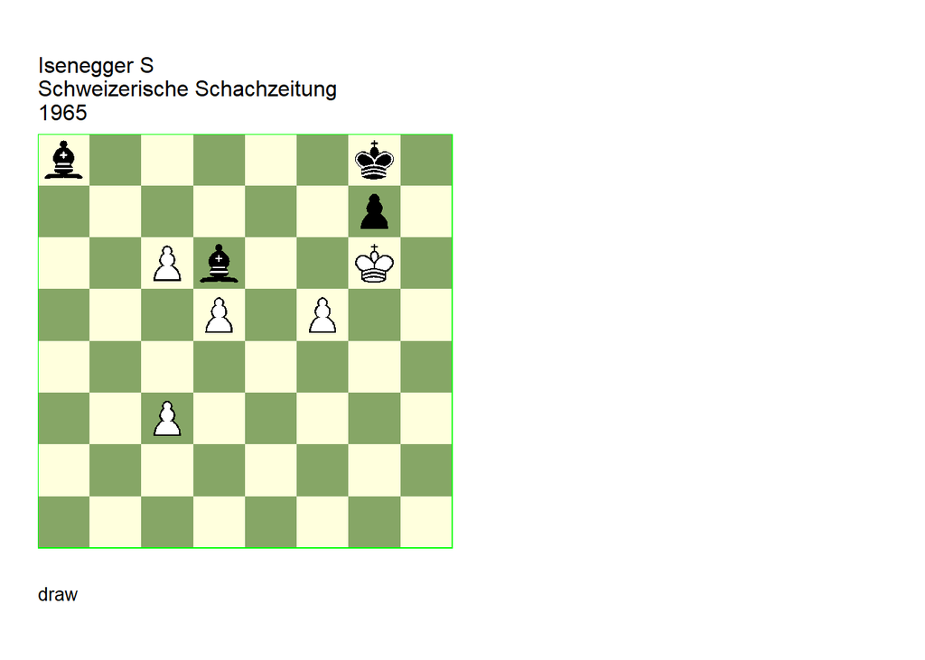

GBR: =0060.41g6g8 PH U2 FEN: b5k1/6p1/2Pb2K1/3P1P2/8/2P5/8/8 w - - 0 1

Schweizerische Schachzeitung=2 Schweizerische Schachzeitung/2. U2: Neuenschwander=B beatochess 19/11/2025. **1. f6 Be5! 2. fxg7 Bxg7! 3. c4 Bd4 4. c5 Bxc5! 5. Kf6 Kf8 6. Ke6 Ke8 7. c7** (7. Kf6! **cook** **BN** 7… Kd8 8. Ke6 Kc7 9. Ke5 =) **7… Bb7 8. d6 Bc8+ 9. Kd5 Bb4 10. Kc6 Bd2 11. d7+ Bxd7+ 12. Kb7 1/2-1/2**.

### 2.1.46 Isenegger =3103.20b2a8 (1965). Cook

**2… Nc5!** cooks the study.

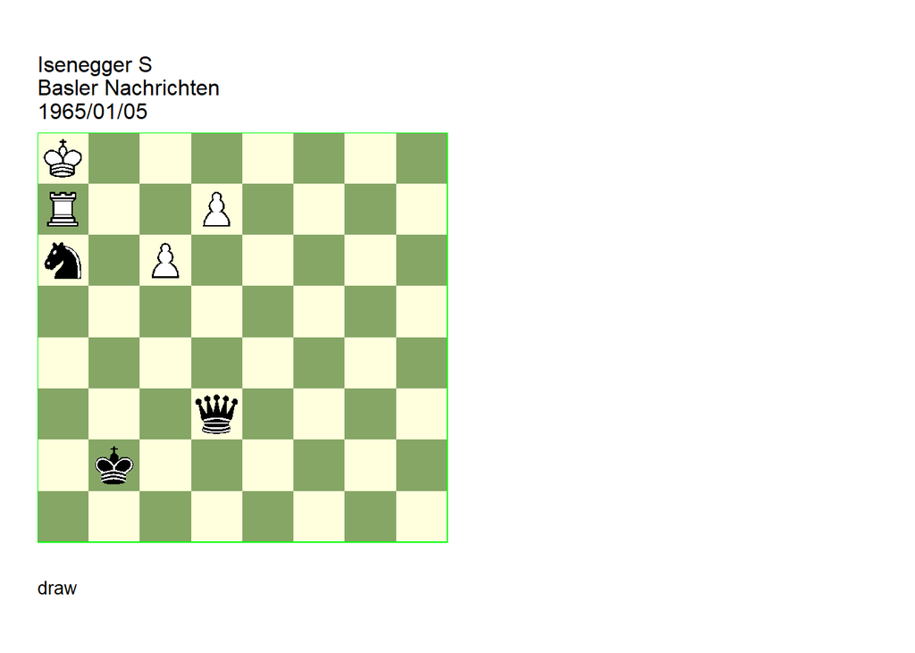

GBR: =3103.20b2a8 PH U3 FEN: K7/R2P4/n1P5/8/8/3q4/1k6/8 w - - 0 1

U3: Neuenschwander=B beatochess 19/11/2025 **1. Rb7+ Kc3 2. Rb8 Nxb8** (2… Nc5! **cook** **BN** ) **3. d8=Q Qxd8 4. c7 Qxc7 1/2-1/2**.

### 2.1.47 Isenegger =0641.20d5f6 (1965). Cook, correction

**1… Rge1!** cooks the study.

File: Isenegger1965c.pgn

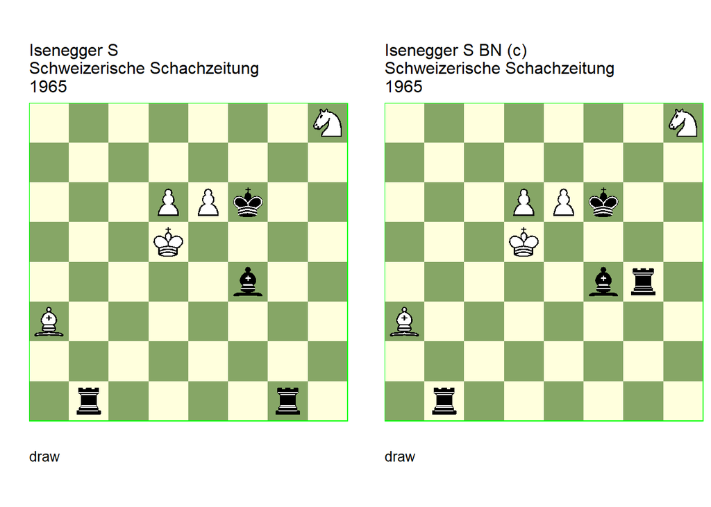

GBR: =0641.20d5f6 PH U3 FEN: 7N/8/3PPk2/3K4/5b2/B7/8/1r4r1 w - - 0 1

Schweizerische Schachzeitung=2 Schweizerische Schachzeitung/2. U3: Neuenschwander=B beatochess 24/11/2025. **1. e7 Rg8** (1… Rge1! **cook** **BN** 2. d7 Rbd1+ 3. Kc6 Re6+) **2. d7 Rbb8 3. d8=Q Rbxd8+ 4. exd8=Q+ Rxd8+ 5. Ke4 Be5 6. Ng6! Rd4+ 7. Ke3 Kxg6 8. Bb2 Rd5 9. Ke4 1/2-1/2**.

GBR: =0641.20d5f6 PH (c) FEN: 7N/8/3PPk2/3K4/5br1/B7/8/1r6 w - - 0 1

correction: Neuenschwander=B beatochess 24/11/2025. **1. e7 Rg8 2. d7 Rbb8 3. d8=Q Rbxd8+ 4. exd8=Q+ Rxd8+ 5. Ke4 Be5 6. Ng6! Rd4+ 7. Ke3 Kxg6 8. Bb2 Rd5 9. Ke4 1/2-1/2**.

# 3 Comments and revisions

## 3.1 Prize winners

### 3.1.1 Pogosyants =0133.33a2d8 (1978). Correction (VH)

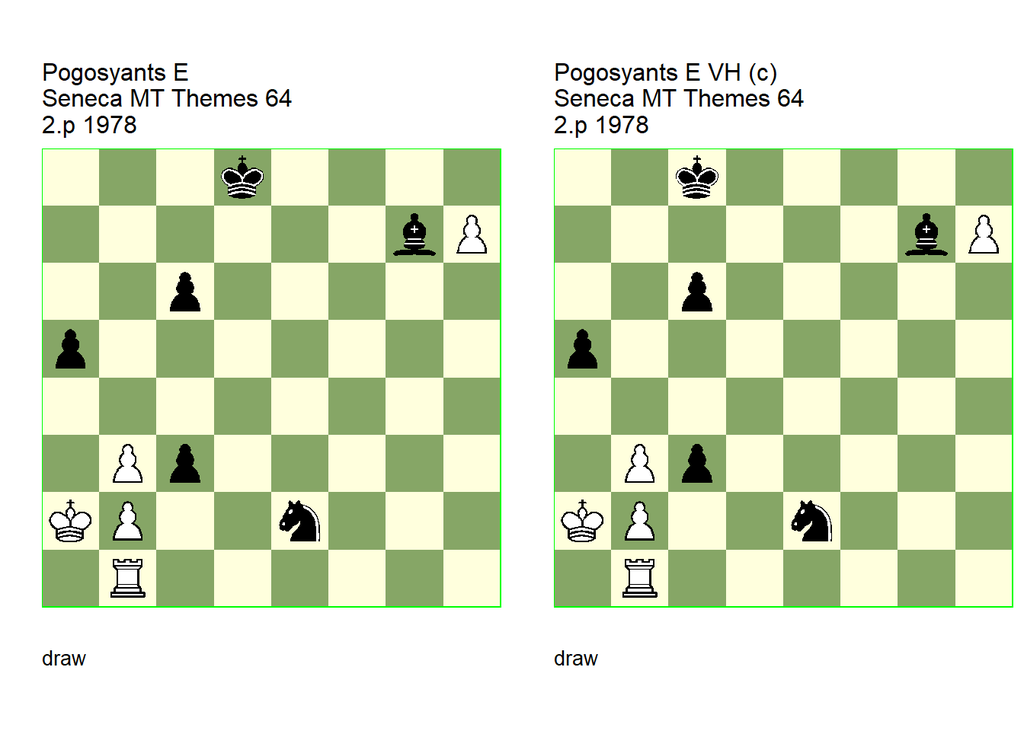

GBR: =0133.33a2d8 U2 FEN: 3k4/6bP/2p5/p7/8/1Pp5/KP2n3/1R6 w - - 0 1

Themes 64=100 Themes 64/12 1980 (EG#04384). U2: Ricci=J HHdbIV#45651 2-12-2007. **1. Rd1+!** (1. Rf1? c2 2. Rf8+ Ke7) **1… Kc8** (1… Ke8 2. Re1!) (1… Kc7 2. Rf1 c2 3. Rf7+ Kb6 4. Rxg7) **2. Rf1!** (2. Re1? c2 3. Rxe2 c1=N+) (2. Kb1! **cook** JR ) **2… c2 3. Rf8+! Bxf8** (3… Kc7 4. Rf7+) **4. h8=Q Nc1+!** (4… c1=Q 5. Qxf8+ Kd7 6. Qf5+ Kd6 7. Qd3+) (4… Kb7 5. Qxf8 Nc1+ 6. Ka3) **5. Ka1 Nd3!** (5… Nxb3+ 6. Ka2 Nc1+ 7. Ka1 Nd3 8. Qxf8+ Kb7 9. Qf7+ Kb6 10. Qb3+) **6. Qh3+** (6. Qxf8+? Kb7 7. Qe7+ Ka6 8. Qe2 c1=Q+ 9. Ka2 Qc4! 10. bxc4 Nc1+) **6… Kb7 7. Qd7+ Kb8 8. Qd8+** (8. Qe8+? Kc7 9. Qf7+ Kb6) **8… Kb7 9. Qd7+** eg **9… Kb6 10. Qd8+** (10. Qd4+? Nc5 11. Qd8+ Kb7) **10… Kc5** ( 10… Kb7 main 11. Qd7+) **11. Qxf8+ 1/2-1/2**.

GBR: =0133.33a2c8 (c) FEN: 2k5/6bP/2p5/p7/8/1Pp5/KP2n3/1R6 w - - 0 1

correction: Hergert=V beatochess 22/11/2025. **1. Rf1 c2 2. Rf8+ Bxf8 3. h8=Q Nc1+ 4. Ka1 Nd3 5. Qh3+ Kb7 6. Qd7+ Kb8 7. Qd8+ Kb7 8. Qd7+ Kb6 9. Qd8+ 1/2-1/2**.

### 3.1.2 Amiryan +0010.13h6h8 (1994). Correction (VH)

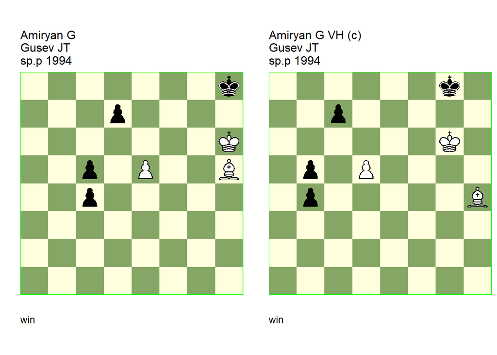

GBR: +0010.13h6h8 U2 FEN: 7k/3p4/7K/2p1P2B/2p5/8/8/8 w - - 0 1

(EG#10828). U2: EG=128 4/1998. **1. Bf7!** (1. Be2? c3 2. Bd3 Kg8 3. Kg6 Kf8 4. Kf6 Ke8 5. Be4 Kd8 6. Kf7 Kc7 7. Ke7 c4!) **1… c3 2. Bb3 c4 3. Bc2 Kg8 4. Kg6 Kf8 5. Kf6 Ke8 6. Be4!** (6. Ba4! **cook** 6… Kd8 (6… Kf8 7. Bxd7 c2 8. e6) 7. Kf7 Kc8 8. Ke8 Kc7 9. Ke7) **6… Kd8** (6… Kf8 7. Bg6!) **7. Kf7 Kc8! 8. Ke8!** (8. Ke7? Kc7) **8… Kc7 9. Ke7! Kc8 10. Kd6 Kd8 11. Bf5 1-0**.

GBR: +0010.13g6g8 (c) FEN: 6k1/2p5/6K1/1p1P4/1p5B/8/8/8 w - - 0 1

correction: Hergert=V beatochess 21/11/2025. **1. Be7!** (1. Be1? b3 2. Bc3 Kf8 3. Kf6 Ke8 4. Ke6 Kd8!1) **1… b3 2. Ba3 b4 3. Bb2 Kf8 4. Kf6 Ke8 5. Ke6 Kd8 6. Bd4!** (6. Be5? Kc8!1) **6… Kc8** (6… Ke8 7. Bf6! +-) **7. Ke7 Kb8!** (7… Kb7 8. Kd7 +-) **8. Kd8!** (8. Kd7? Kb7!1) **8… Kb7 9. Kd7! Kb8** ( 9… b2 10. Bxb2 Kb6 11. Bd4+ Kb5 12. Kxc7 +-) **10. Kc6 1-0**.

### 3.1.3 Kralin & Pervakov +0040.12g5d1 (1997). Minor dual (no cook) (VH)

The study is correct: **13. Qg4+** is winning in the same way as **13. Qf2+**, but it loses time.

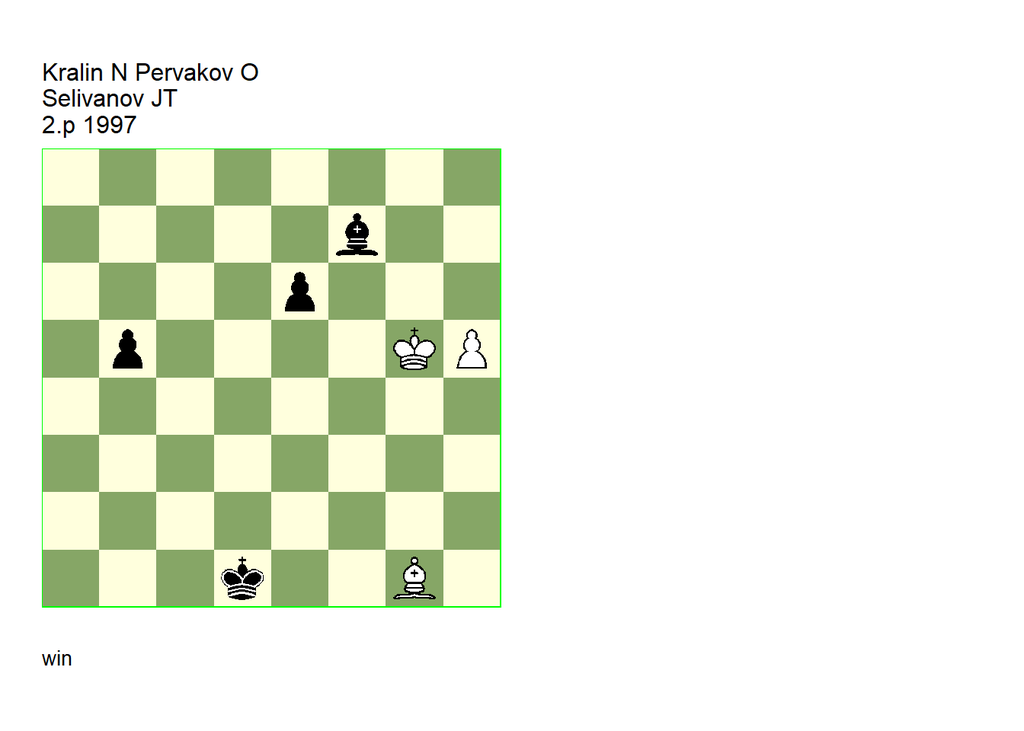

GBR: +0040.12g5d1 (U2) FEN: 8/5b2/4p3/1p4KP/8/8/8/3k2B1 w - - 0 1

(EG#13562). (U2): Campioli=M EG=149 7/2003, Hergert=V beatochess 21/11/2025. **1. h6 Bg8 2. Kg6! e5 3. Kg7 Bh7!** (3… b4 4. Bc5! (4. Bh2? e4) 4… b3 5. Ba3 e4 6. Kxg8) **4. Kxh7 b4 5. Bc5!** (5. Bh2? e4 6. Kg8 b3 7. Be5 e3 8. h7 e2 9. Bc3 b2! (9… e1=Q? 10. Bxe1 b2 11. h8=Q b1=Q 12. Qd4+! Ke2 (12… Kxe1 13. Qg1+) 13. Qf2+ Kd3 14. Qf5+) 10. h8=Q b1=Q 11. Qd4+ Kc2!) **5… b3 6. Ba3 e4 7. Kg8!** (7. Kg6? e3 8. h7 e2 9. Bb4 b2 10. h8=Q b1=Q+) (7. Kg7? e3 8. h7 e2 9. Bb4 b2 10. h8=Q b1=Q) **7… e3 8. h7 e2 9. Bb4 e1=Q** (9… b2 main 10. h8=Q b1=Q 11. Qd4+! Kc2 12. Qc3+ Kd1 13. Qd2#) **10. Bxe1 b2 11. h8=Q b1=Q 12. Qd4+! Ke2** (12… Kxe1 13. Qg1+) **13. Qf2+** (13. Qg4+ **cook** MC minor (waste of time) **dual** VH 13… Ke3 14. Qg1+ Ke2 15. Qf2+ Kd3 16. Qf5+) **13… Kd3** (13… Kd1 14. Qd2#) **14. Qf5+ Ke2 15. Qxb1 1-0**.

### 3.1.4 Aliev +0030.40a8e6 (1999). Correction (VH)

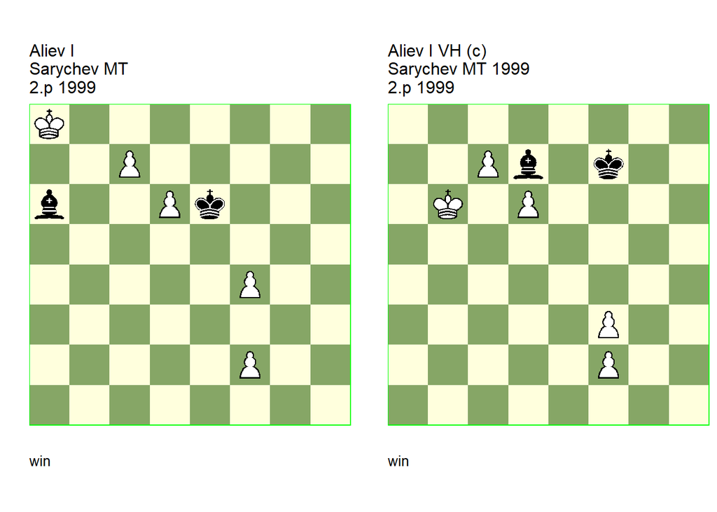

GBR: +0030.40a8e6 (m) U3 FEN: K7/2P5/b2Pk3/8/5P2/8/5P2/8 w - - 0 1

(EG#14361a). U3: Campioli=M Beasley=J EG=157 10/2005. **1. Ka7 Bc8 2. Kb8 Bd7** ( 2… Kd7! **cook** MC/JB ) **3. c8=Q Bxc8 4. Kc7 Kd5 5. f3 Kc5 6. d7 Bxd7 7. Kxd7 Kd5 8. Ke7 1-0**.

GBR: +0030.40b6f7 FEN: 8/2Pb1k2/1K1P4/8/8/5P2/5P2/8 w - - 0 1

correction: Hergert=V beatochess 21/11/2025. **1. f4!** (1. Kb7? Ke6 2. c8=Q Bxc8+ 3. Kxc8 Kxd6!1) **1… Ke6 2. c8=Q Bxc8 3. Kc7 Kd5** (3… Bd7 4. f5+ Kxf5 5. Kxd7 +-) **4. f3!** (4. Kxc8? Kxd6!1) (4. d7? Bxd7 5. Kxd7 Ke4!1) **4… Kc5** (4… Bf5 5. d7 Bxd7 6. Kxd7 +-) (4… Ke6 5. f5+ Kd5 (5… Kxf5 6. Kxc8 +-) 6. f6 +-) **5. d7 Bxd7 6. Kxd7 Kd5 7. Ke7 1-0**.

### 3.1.5 Koranyi +3054.22f8h4 (1996). Version (VH)

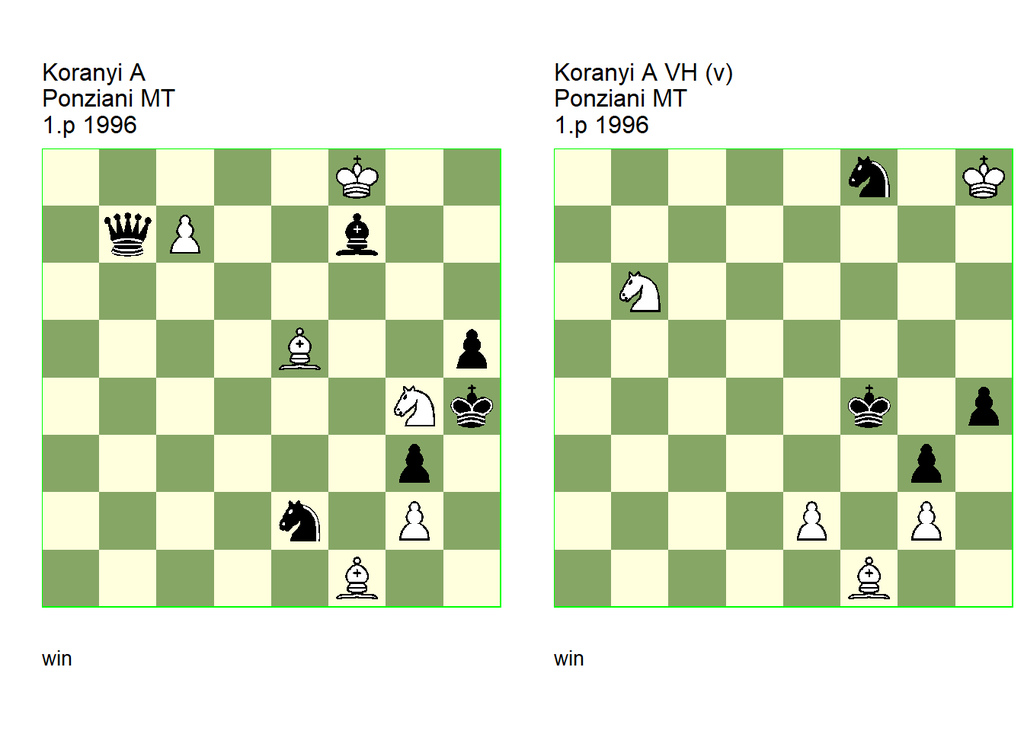

GBR: +3054.22f8h4 TT U3 FEN: 5K2/1qP2b2/8/4B2p/6Nk/6p1/4n1P1/5B2 w - - 0 1

(EG#11082). U3: EG=131 1/1999. **1. Nh6!** (1. Ne3? Qc6 2. c8=Q Qxc8+ 3. Kg7 Qg8+) **1… Qc6** (1… Kg5 2. Nxf7+ Kg6 3. Bxe2) **2. c8=Q!** (2. Nxf7? Nd4 3. Bxd4 Qxc7 4. Be2 Qe7+) **2… Qxc8+** (2… Qxh6+ 3. Kxf7 Qh7+ 4. Bg7) **3. Kg7 Qe6! 4. Bf6+ Qxf6+ 5. Kxf6 Bc4!** (5… Bg6 6. Kxg6! Nf4+ 7. Kf6 Nxg2 8. Nf5+! Kg4 9. Bxg2 h4 10. Ne3+ Kf4 11. Nc4 h3 12. Bxh3 Kf3 13. Ne5+ Kf2 14. Nd3+) **6. Nf5+ Kg4 7. Ne3+ Kf4 8. Nxc4 h4!** (8… Nd4 9. Ne5 Ke3 10. Ba6 Kf2 11. Bb7 h4 12. Ng4+) (8… Nc3 9. Kg6 h4 10. Kh5 h3 11. gxh3 Kf3 12. h4 Kf2 13. Bh3 g2 14. Bxg2) (8… Ng1! **cook** 9. Bd3 (9. Ne5 Ke3 10. Nd3 (10. Ba6 h4 11. Bc8 Kf2) 10… h4) (9. Kg6 h4 10. Kh5 Nf3 11. gxf3 Kxf3) 9… h4 10. Bf5 h3) **9. Ne5!** (9. Kg6? Nd4! 10. Kh5 Nf5!) **9… Ke3 10. Ng4+ Kf4 11. Bxe2 h3 12. Nf2! hxg2** (12… gxf2 13. gxh3) (12… h2 13. Nh1) **13. Nh3+ Ke3 14. Bg4!** ( 14. Ba6? g1=Q 15. Nxg1 g2!) **14… g1=Q 15. Nxg1 Kf2 16. Nh3+ Kf1 17. Nf4 g2 18. Bh3 1-0**.

GBR: +0014.22h8f4 TT (v) FEN: 5n1K/8/1N6/8/5k1p/6p1/4P1P1/5B2 w - - 0 1

version: Hergert=V beatochess 14/11/2025. **1. Kg7 Ne6+ 2. Kf6 Nd4 3. Nc4!** ( 3. Nd5+? Ke4 4. Nc3+ Ke3 5. Kg5 (5. Nd1+ Kd2!1) 5… Kf2 6. Kxh4 Nf5+ 7. Kh3 Ne3!1) **3… Nxe2! 4. Ne5!** (4. Bxe2? h3 5. Bf3 h2 6. Nb6! Ke3!1) **4… Ke3 5. Ng4+** (5. Nc4+? Kf2!1) **5… Kf4** (5… Kd2 6. Kg5! Ke1 7. Bxe2 h3 8. Bf3! h2 9. Nxh2 +-) **6. Bxe2** (6. Ne5 Ke3 7. Ng4+ waste of time ) **6… h3 7. Nf2!** (7. gxh3?? g2 -+) (7. Bf3?? h2 -+) **7… hxg2** (7… gxf2 8. gxh3 +-) (7… h2 8. Nh1 +-) (7… Ke3 8. Nxh3 +-) **8. Nh3+ Ke3 9. Bg4! g1=Q 10. Nxg1 Kf2** (10… g2 11. Nh3 +-) **11. Nh3+** (11. Nf3? g2!1) **11… Kg2 12. Nf4+** (12. Kf5? Kh2 13. Nf4 g2!1) **12… Kf2 13. Bh3 g2 14. Bxg2** (14. Nxg2? Kg3!1) **1-0**.

### 3.1.6 Zamotaev =0353.20h3f5 (1995). Correction (VH)

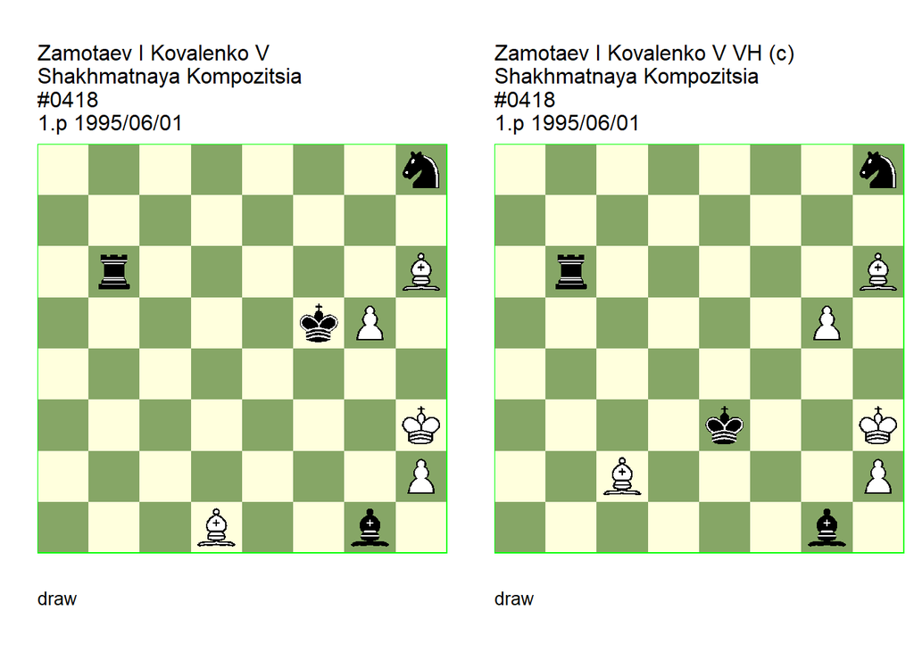

GBR: =0353.20h3f5 U2 FEN: 7n/8/1r5B/5kP1/8/7K/7P/3B2b1 w - - 0 1

Shakhmatnaya Kompozitsia=10 . U2: Garcia=M HHdbV#18489 23-9-2011. **1. Bc2+ Kf4!** (1… Ke5 2. Bg7+) (1… Ke6 2. g6 Nxg6 (2… Bd4 3. g7 Rb8 4. g8=Q+! Rxg8 5. Bb3+) 3. Bxg6) **2. g6+** (2. Kg2! **cook** MG 2… Rb2 3. g6+ Kg4 4. h3+ Kh4 5. g7) **2… Kf3! 3. Bd1+ Ke4! 4. Bc2+! Kf3! 5. Bd1+ Kf2 6. Be3+!** (6. g7? Rxh6+ 7. Bh5! Rxh5+ 8. Kg4 Rxh2! 9. Kf5 (9. Kf4 Ng6+) 9… Nf7! 10. g8=Q Nh6+) **6… Kxe3 7. g7 Rh6+** (7… Rb8 8. Bb3!) **8. Bh5! Rxh5+ 9. Kg4! Rxh2!** (9… Rh6 10. Kf5! Ng6 11. Kg5) **10. Kg3! Rh6! 11. Kg2! Rg6+ 12. Kh1! Rh6+** (12… Nf7 main 13. g8=Q! Rxg8) **13. Kg2! Bf2 14. g8=Q Rg6+ 15. Kf1! Rxg8 1/2-1/2**.

GBR: =0353.20h3e3 (c) FEN: 7n/8/1r5B/6P1/8/4k2K/2B4P/6b1 w - - 0 1

correction: Hergert=V beatochess 11/11/2025. **1. g6+** (1. Kg2? Kd2! 2. Be4 Be3 -+) **1… Kf3 2. Bd1+ Ke4 3. Bc2+ Kf3 4. Bd1+ Kf2 5. Be3+ Kxe3 6. g7 Rh6+** ( 6… Rb8 7. Bb3!) **7. Bh5! Rxh5+ 8. Kg4! Rxh2!** (8… Rh6 9. Kf5! Ng6 10. Kg5) **9. Kg3! Rh6! 10. Kg2! Rg6+ 11. Kh1! Rh6+** (11… Nf7 main 12. g8=Q! Rxg8) **12. Kg2! Bf2 13. g8=Q Rg6+ 14. Kf1! Rxg8 1/2-1/2**.

### 3.1.7 Antipin =0031.12b3b5 (2004). Cook (VH)

**5… Ka4** cooks the study (tablebase).

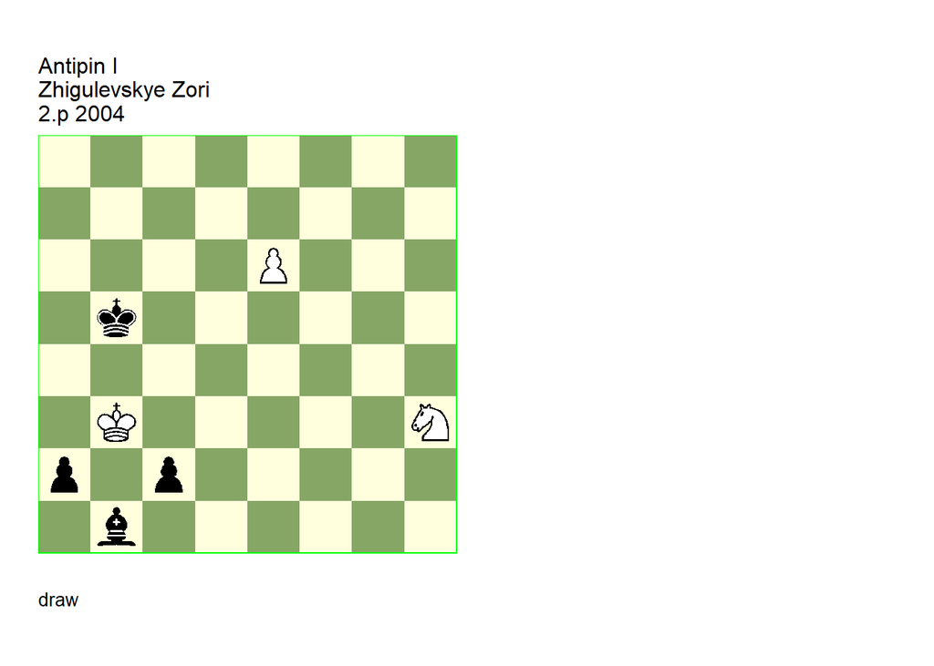

GBR: =0031.12b3b5 U3 FEN: 8/8/4P3/1k6/8/1K5N/p1p5/1b6 w - - 0 1

U3: Hergert=V beatochess 10/11/2025. **1. e7 c1=N+ 2. Kb2 Bg6 3. Nf4 Bf7 4. Ne6 Nd3+ 5. Ka1 Nb4** (5… Ka4! **cook** VH Other Black moves also win according to TB 6. Nd4 Kb4 7. e8=Q Bxe8 8. Kxa2 Ba4 -+ TB DTZ 172 ) **6. Kb2 Ka5 7. Nc5 Kb6 8. Ne6 Nc2 9. Kxa2 Bxe6+ 10. Kb2 1/2-1/2**.

### 3.1.8 Becker =0137.12h5c4 (2004). Cook? Version (VH)

The study is analycally heavy. In particular, after **6. Rh4** the position is rather unclear. Volker suggests a clearer version.

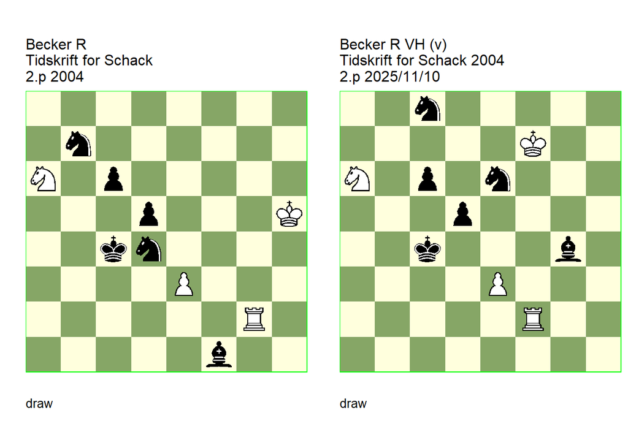

GBR: =0137.12h5c4 U2? FEN: 8/1n6/N1p5/3p3K/2kn4/4P3/6R1/5b2 w - - 0 1

Tidskrift for Schack=3 2005 (EG#15926). Comments: Hergert=V beatochess 10/11/2025. **1. Rf2!** (1. Rg4? Be2) (1. Rg6? Be2+ 2. Kg5 (2. Kh4 Nf5+ 3. Kg5 Nbd6) 2… Nc5 3. Nb8 Nf3+ 4. Kf4 (4. Kh6 Ne5) 4… Nd3+ 5. Kg3 c5) (1. Rg7? Be2+ 2. Kg6 Bd3+ 3. Kh5 (3. Kf6 Nd6 4. Ke5 N4b5 5. Rg1 (5. Nb8 Kc5 6. Nd7+ Kb4 7. Nb8 Nc4+ 8. Ke6 Na5) 5… Ne4 6. Nb8 c5 7. Nd7 Nec3 8. Nb6+ Kb3 9. Nxd5 Nxd5 10. Kxd5 c4) 3… Nc5 4. Nb8 (4. Nxc5 Kxc5 5. exd4+ Kxd4 6. Kg4 Be4) 4… Nde6 5. Rg2 (5. Rg8 Ne4) 5… Nd8) **1… Be2+** (1… Bd3 2. exd4 Kxd4 3. Nc7 Ke5 (3… c5 4. Rb2 Nd6 5. Ne6+ Kc4 6. Kg5) 4. Rf7 Nc5 (4… d4 5. Kg4 c5 6. Ne8 Na5 7. Re7+ Kd5 8. Kf4) 5. Kg4 Be2+ 6. Kg3 Ne4+ 7. Kg2 Kd6 (7… d4 8. Re7+ Kf4 9. Ne6+ Ke3 10. Ng5 Bd3 11. Ne6) (7… c5 8. Rd7 Nc3 9. Kf2 d4 10. Re7+ Kd6 11. Rh7 d3 12. Ke3 c4 13. Kd2 Nb1+ 14. Ke3 c3 15. Nb5+) 8. Ne8+ Ke6 9. Rf8 Ke5 10. Nc7 Kd6 11. Ne8+ Ke7 12. Rh8 c5 13. Ng7 Bg4 14. Nh5 c4 15. Ng3 Nf6 16. Kf2 d4 17. Ke1) **2. Kg5** (2. Kh4? Kd3 3. exd4 Ke3 4. Rxe2+ Kxe2) **2… Nd6** (2… Nf3+ 3. Kf4) (2… Ne6+ 3. Kf6) (2… Kc3 3. Nb8 Nd6 4. Kf4 N6b5 5. exd4) **3. Kf4** (3. exd4? Ne4+ 4. Kf4 Nxf2) **3… Ne4 4. Rh2** (4. Rg2? Bf1) **4… Ne6+ 5. Ke5** (5. Kf5? Nd8) **5… Bg4 6. Rg2!** (6. Rc2+? Kb5 7. Rb2+ Kxa6 8. Rb6+ Ka5 9. Rxc6 N4g5 10. Kxd5 Bf3+ 11. Kd6 Nf7+) (6. Rh4? **cook**? VH 6… Nf2 7. Rh2 (7. Kd6 **cook**? 7… c5 8. Rh2 Ne4+ 9. Ke5 Nf8 10. Rc2+ Kb3 11. Rc1 c4 12. Kxd5 Nc3+ 13. Kd6 Nd7 14. Nc7 VH: is this a draw or won for Black? There so many possibilities… Stockfish evaluation around -0.8… ) 7… Nd1 8. Rc2+ ( 8. Kd6 Nxe3) 8… Kb5 9. Nb8 c5) (6. Rb2) **6… Bh3** (6… Bf3 7. Rc2+ Kb5 8. Kxe6 Kxa6 9. Rxc6+) **7. Rc2+** (7. Rg1? N6g5 8. Rc1+ Nc3 9. Kd6 Kb5) (7. Rh2? N6g5 8. Rc2+ Nc3 9. Kd6 Bf5 10. Rg2 (10. Rc1 Kb5 11. Ke5 Bc8) 10… Nf7+ 11. Kxc6 d4) **7… Kb5** (7… Nc3 8. Nb8 c5 (8… Nd8 9. Rh2 Bc8 10. Kd6) 9. Nd7 d4 ( 9… Kd3 10. Rh2) 10. exd4 cxd4 11. Rd2 Nb5 12. Nb6+ Kc3 (12… Kc5 13. Na4+) 13. Rh2) **8. Rb2+** (8. Nb8? N6c5 9. Rb2+ Kc4 10. Rc2+ Kd3 11. Rh2 Nd7+) **8… Kxa6** (8… Ka4 9. Rb6 Nd8 10. Nc7) **9. Rb6+ Ka7** (9… Kxb6 main ) **10. Rb7+** ( 10. Rxc6? Kb7 11. Kxd5 (11. Rc2 Nc7) 11… Nf6+ 12. Kd6 Ne8+) **10… Ka8 11. Rb8+ Ka7 12. Rb7+ Ka6 13. Rb6+ Ka5 14. Rxc6 N4c5** (14… N4g5 15. Rc2) (14… Kb5 15. Rc2) **15. Kxd5** (15. Rd6? Nc7 16. Rc6 N7a6 17. Kxd5 Bg2+ 18. Kd6 Nb7+) **15… Bg2+** (15… Kb5 16. Rd6) **16. e4 Bxe4+ 17. Kd6 Nb7+ 18. Kd7 Nec5+ 19. Kc7 Na6+ 20. Kc8 Bf5+** (20… Bxc6 main ) **21. Kxb7 Be4 22. Ka7 Bxc6 1/2-1/2**.

GBR: =0137.12f7c4 FEN: 2n5/5K2/N1p1n3/3p4/2k3b1/4P3/5R2/8 w - - 0 1

version: Hergert=V beatochess 11/11/2025. **1. Kf6!** (1. Nb8? c5) (1. Rc2+? Kb5 2. Nb8 Nd6+! -+) (1. Rg2? Nd6+ 2. Kf6 Bh3! 3. Rh2 Ne4+ 4. Ke5 N6g5! 5. Rc2+ Nc3! 6. Kd6 Bc8! 7. Nc7 Bb7! -+) **1… Nd6 2. Ke5!** (2. Rb2? Kc3! 3. Rb6 Nd8 4. Nb4 Bf3! 5. Nxc6 Nc4! 6. Nxd8 Nxb6 -+) **2… Ne4 3. Rg2 Bh3 4. Rc2+ Kb5 5. Rb2+ Kxa6 6. Rb6+ Ka7 7. Rb7+ Ka8 8. Rb8+ Ka7 9. Rb7+ Ka6 10. Rb6+ Ka5 11. Rxc6 N4c5 12. Kxd5 Bg2+ 13. e4 Bxe4+ 14. Kd6 Nb7+ 15. Kd7 Nec5+ 16. Kc7 Na6+ 17. Kc8 Bf5+ 18. Kxb7 Be4 19. Ka7 Bxc6 1/2-1/2**.

## 3.2 Misc

### 3.2.1 Gurgenidze =0400.01h1g4 (1987). Correction

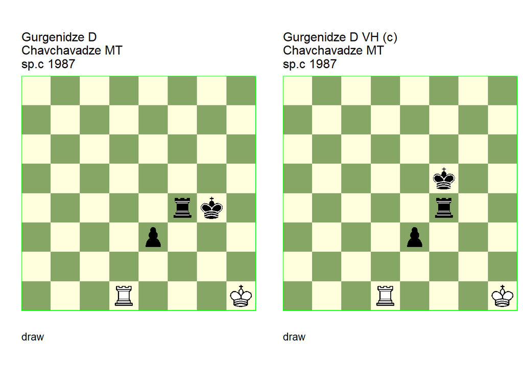

GBR: =0400.01h1g4 U3 FEN: 8/8/8/8/5rk1/4p3/8/3R3K w - - 0 1

(EG#07802). U3: Nunn=J Secrets of Rook Endings#445 1992. **1. Kg2** (1. Kg1? e2 2. Ra1 Kg3) **1… Rf2+ 2. Kg1 Kf3** (2… e2 main 3. Rd4+ Kg3 4. Rg4+! Kf3 5. Rf4+! Ke3 6. Re4+! Kf3 7. Rf4+ Kxf4 8. Kxf2) (2… Ra2! **cook** JN 3. Rf1 Kg3 4. Rb1 Ra3 5. Kf1 Kf3! 6. Ke1 Ra8 7. Kf1 Rh8 8. Kg1 Rg8+ 9. Kf1 e2+) **3. Rf1! Ke2 4. Ra1 Kf3 5. Rf1 Kg3** (5… Rxf1+ 6. Kxf1) **6. Rxf2 exf2+ 7. Kf1 Kf3 1/2-1/2**.

GBR: =0400.01h1f5 (c) FEN: 8/8/8/5k2/5r2/4p3/8/3R3K w - - 0 1

correction: Hergert=V 24/11/2025. **1. Kg1!** (1. Kg2? Kg4 2. Re1 Rf2+ 3. Kg1 Kf4! -+ (3… Kf3? 4. Rf1 Ke2 5. Ra1!!1) ) **1… Kg4** (1… Rg4+ 2. Kf1!1) (1… Ke4 2. Ra1! see **main** line ) **2. Re1 Kf3 3. Rf1+ Kg3 4. Re1!** ( 4. Rxf4? Kxf4 5. Kf1 Kf3 6. Ke1 e2 7. Kd2 Kf2 -+) **4… Kf3** (4… Rf3 5. Re2!1) **5. Rf1+ Ke4 6. Ra1! Rg4+** (6… e2 7. Kg2 Kd3 (7… Rg4+ 8. Kf2 Kd3 9. Ra3+!1) 8. Ra3+ Kc2 9. Ra2+!1) **7. Kf1 Kf3 8. Ra2 Rh4 9. Rf2+ exf2 1/2-1/2**.

### 3.2.2 Bazlov +0411.01f6d1 (1994). Correction

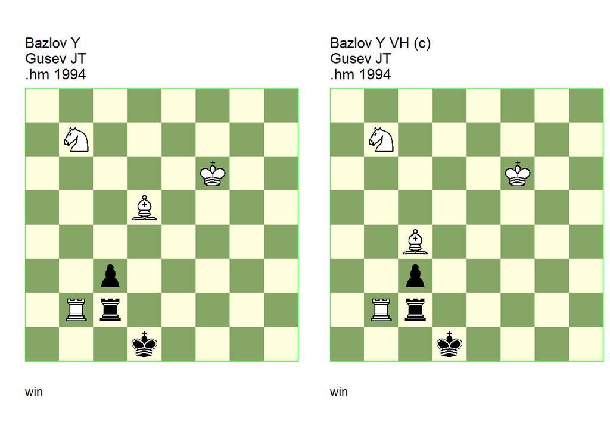

GBR: +0411.01f6d1 U2 FEN: 8/1N6/5K2/3B4/8/2p5/1Rr5/3k4 w - - 0 1

(EG#10832). U2: EG=128 4/1998. **1. Rb1+** (1. Rb4? Rf2+) **1… Rc1 2. Rb4!** ( 2. Rb6! **cook** 2… c2 3. Be4 Kd2 (3… Ra1 4. Rd6+ Kc1 5. Rc6 Ra2 6. Nc5) 4. Ke5 Re1 5. Rd6+ Kc1 (5… Kc3 6. Rc6+ Kb3 7. Nc5+ Ka3 8. Nd3) 6. Nc5 Kb1 7. Nd3 c1=Q 8. Nxe1+ Ka2 9. Ra6+ Kb3 10. Bd5+) **2… c2 3. Nc5 Rb1 4. Bb3 Rb2!** ( 4… Kd2 5. Rd4+ Kc3 6. Rc4+) **5. Ke5! Kc1!** (5… Kd2 6. Rd4+ Kc3 7. Rc4+ Kd2 8. Ne4+ Kd1 9. Ba4 Ra2 10. Nc3+) **6. Nd3+ Kd2** (6… Kb1 7. Bxc2+! (7. Ba2+? Ka1 8. Rxb2 c1=Q 9. Nxc1 Kxb2) ) **7. Rd4! Kc3** (7… c1=Q 8. Nxc1+ Kxc1 9. Rd1#) (7… Rxb3 8. Nc5+ Kc3 9. Na4#) **8. Nc1 Rb1 9. Rc4+ Kd2! 10. Rxc2+ Kd1! 11. Ba4!** (11. Rc8+? Kd2 12. Rc2+ Kd1) (11. Rc3+! **cook** 11… Kd2 12. Na2) **11… Rxc1 12. Rh2+!** (12. Rg2+? Ke1 13. Bc2 Kf1 14. Rh2 Kg1) **12… Ke1 13. Bc2! 1-0**.

GBR: +0411.01f6d1 (c) FEN: 8/1N6/5K2/8/2B5/2p5/1Rr5/3k4 w - - 0 1

correction: Hergert=V beatochess 24/11/2025. **1. Rb1+ Rc1 2. Rb4** (2. Rb6? c2 3. Bd3 Ra1!1) **2… c2 3. Nc5 Rb1 4. Bb3 Rb2 5. Ke5 Kc1 6. Nd3+ Kd2 7. Rd4 Kc3 8. Nc1 Rb1 9. Rc4+ Kd2 10. Rxc2+ Kd1 11. Ba4 Rxc1 12. Rh2+ Ke1 13. Bc2 +- 1-0**.

### 3.2.3 Sukhitashvili +0011.02d2f5 (1991). Minor dual (no cook) (VH)

The study is correct. **2. Bh2** leads to the mainline.

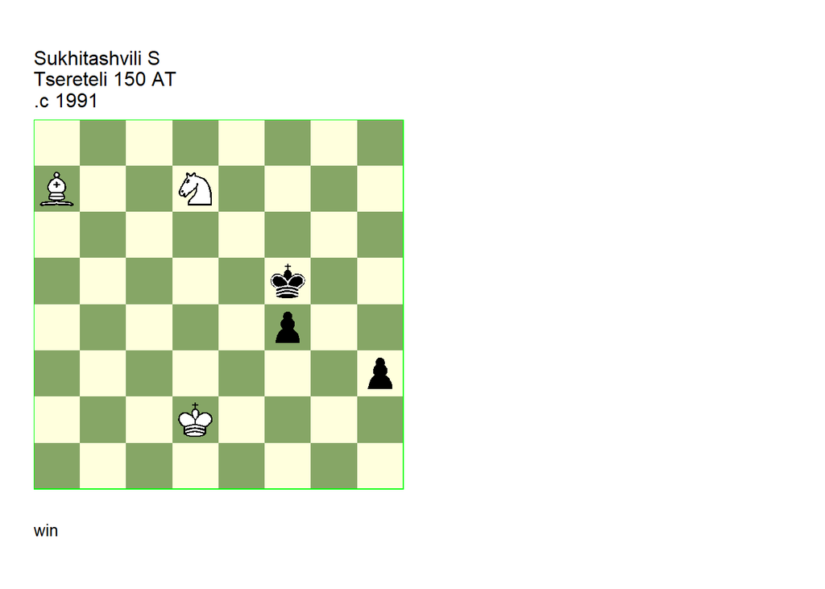

GBR: +0011.02d2f5 U2 FEN: 8/B2N4/8/5k2/5p2/7p/3K4/8 w - - 0 1

(EG#09127). U2: (HHdbIII#10446 2004). (U2): Hergert=V beatochess 24/11/2025. **1. Bg1 Kg4 2. Ke2** (2. Bh2 **cook**(move order) **dual** VH 2… Kf3 3. Ne5+ Kf2 ( 3… Kg2 4. Ke2 =main ) 4. Nd3+ Kg2 5. Ke1 f3 6. Nf4+ Kh1 7. Kf1 f2 8. Ke2 f1=Q+ 9. Kxf1 Kxh2 10. Kf2 Kh1 11. Ne2 Kh2 12. Nc3 Kh1 13. Ne4 Kh2 14. Nd2 Kh1 15. Nf1 h2 16. Ng3#) **2… Kg3 3. Bh2+ Kg2** (3… Kxh2 main 4. Kf2 Kh1 5. Ne5 Kh2 6. Ng4+ Kh1 7. Kf1 f3 8. Kf2 h2 9. Kf1 f2 10. Nxf2#) **4. Ne5 Kxh2 5. Kf2 Kh1 6. Ng4** (6. Nd3? f3 7. Kf1 Kh2) **6… f3 7. Kf1 f2 8. Nxf2+ Kh2 9. Ne4 Kh1 10. Kf2 Kh2 11. Nd2 Kh1 12. Nf1 h2 13. Ng3# 1-0**.

### 3.2.4 Mitrofanov +0101.24b5e5 (1975). Correction (VH)

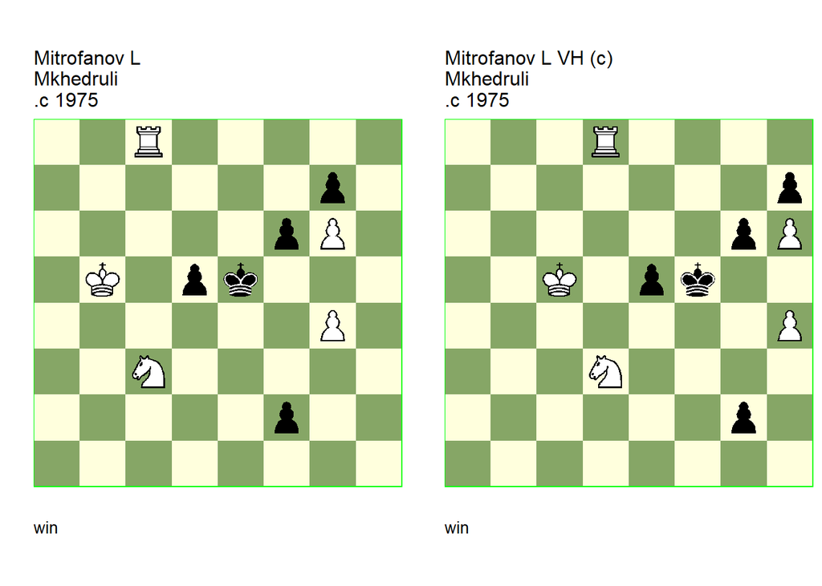

GBR: +0101.24b5e5 U3 FEN: 2R5/6p1/5pP1/1K1pk3/6P1/2N5/5p2/8 w - - 0 1

(EG#02954). U3: De, Zeeuw=M HHdbIV#42270 4-9-2005. **1. Ne2 f1=Q 2. Kc6 f5 3. g5 f4 4. Re8+ Kf5 5. Ng3+ fxg3 6. Rf8+ Kxg6!** **cook** MZ (6… Ke4! **cook** MZ 7. Rxf1 d4 8. Kc5 Ke3! 9. Kc4 g2 10. Rd1 Ke2 11. Rg1 (11. Ra1 d3 12. Kc3 d2 13. Kc2 Kf2 14. Kxd2 g1=Q 15. Rxg1 Kxg1) 11… Kf2 12. Ra1 Ke3) **7. Rxf1 Kxg5 8. Kxd5 Kg4 1-0**.

correction: Hergert=V beatochess 21/11/2025. **1. Nf2!** (1. Rf8+? Ke6 2. Re8+ Kf7 3. Nxe5+ Kxe8 4. Nf3 Kf7 5. Kd4 g5 6. hxg5 Kg6 7. Ke3 g1=Q+ 8. Nxg1 Kxg5!1) (1. Kd6? Kg4 2. Nxe5+ Kg3!1) **1… g1=Q 2. Kd6 g5** (2… Qxf2 3. Rf8+ Kg4 4. Rxf2 +-) (2… Kf4 3. Nh3+) **3. h5 g4 4. Rf8+ Kg5 5. Nh3+! gxh3 6. Rg8+ Kxh6 7. Rxg1 Kxh5 8. Kxe5 Kh4 9. Kf4** (9. Kf5? h2!1) **1-0**.

### 3.2.5 Katsnelson +0401.11e5a7 (1996). Comments, cooks (VH)

**1.Ne6** is not a cook. The study is cooked for other reasons (cooks on moves 2 and 3).

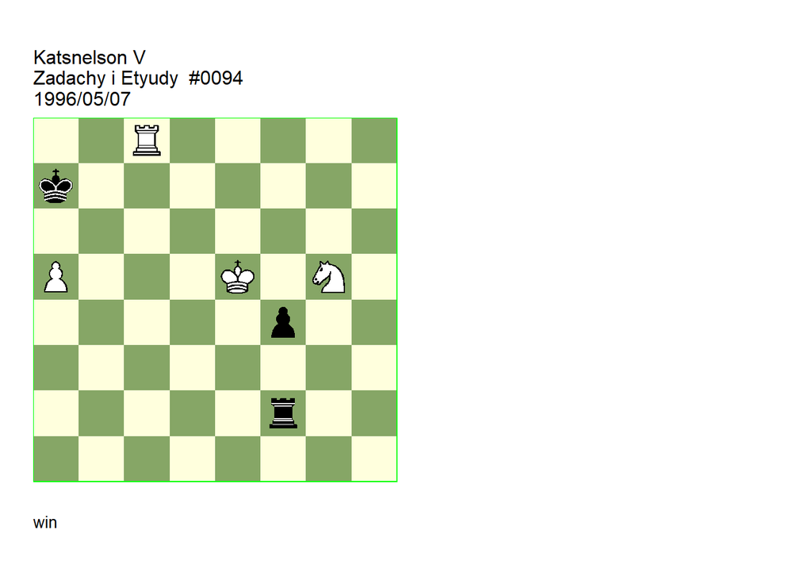

GBR: +0401.11e5a7 U1 FEN: 2R5/k7/8/P3K1N1/5p2/8/5r2/8 w - - 0 1

Zadachy i Etyudy=10 . U1: Golomedov=A Zadachy i Etyudy=12 1996 22-4-1997. U3: Hergert=V beatochess 13/11/2025 **1. Ne4** (1. Ne6! **cook** AG 1… Ra2 (1… f3!!1 no **cook**, VH ) 2. Rc5 f3 3. Kd6 f2 4. Rf5 f1=Q (4… Ka6!!1 no **cook**, VH ) 5. Rxf1 Rxa5 6. Kc7) **1… Ra2** (1… Kb7 2. Nxf2 Kxc8 3. Ne4 Kb7 4. Nc5+! Kc6 5. a6) **2. Rc7+ Ka6** (2… Ka8! **cook** VH 3. Kd6 Rxa5 =) (2… Kb8! **cook** VH 3. Kd6 Rxa5!1) **3. Kd5!** (3. Nc5+? Kb5 4. a6 f3) **3… Ra3** (3… Rxa5+ 4. Nc5+!) (3… Re2! **cook**s VN or Rg2/Rh2 ) **1-0**.

### 3.2.6 Radchenko =0400.02a5e6 (1993). Correction (VH)

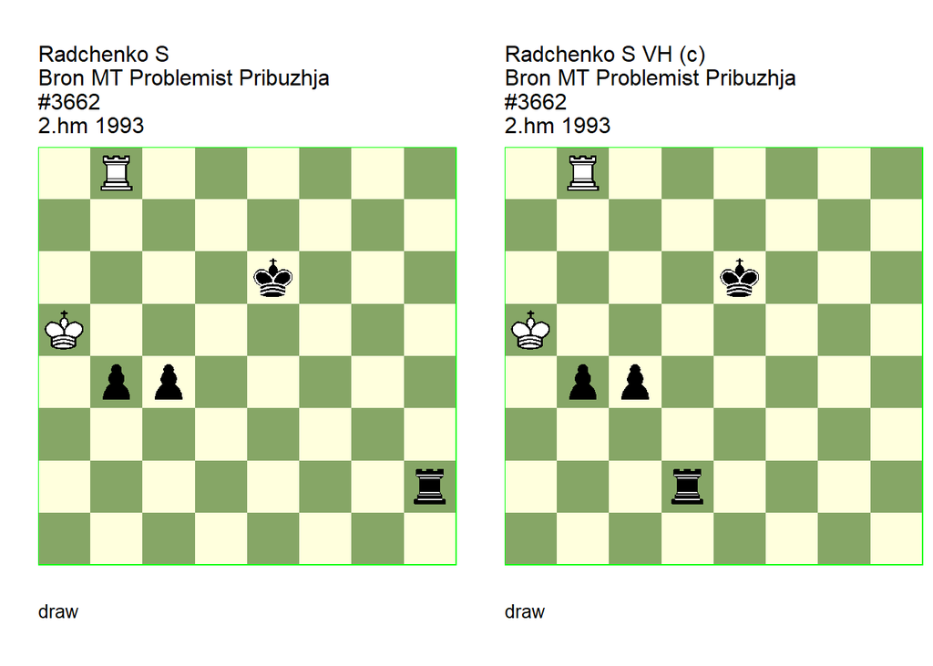

GBR: =0400.02a5e6 U1 FEN: 1R6/8/4k3/K7/1pp5/8/7r/8 w - - 0 1

also .c Mitrofanov MT Vecherny Peterburg 1994 (EG#09911). U1: Conrady=H HHdbIII#08885 1-4-2005. **1. Re8+** (1. Rxb4 Kd5 2. Rb5+! **cook** HC ) (1. Rc8? b3 2. Rxc4 Rh8! (2… b2? 3. Rb4 Kd5 4. Kb6! (4. Ka4? Rh4) (4. Rb3? Kc4 5. Ka4 b1=Q 6. Rxb1 Ra2#) ) ) **1… Kd7 2. Re4 b3 3. Rxc4 b2 4. Rb4 Kc7 5. Rb3 1/2-1/2**.

GBR: =0400.02a5e6 (c) FEN: 1R6/8/4k3/K7/1pp5/8/3r4/8 w - - 0 1

correction: Hergert=V beatochess 12/11/2025. **1. Re8+** (1. Rxb4? Kd5 2. Rb5+ Kd4 3. Rh5 Kc3 4. Rh3+ Rd3 -+) (1. Rc8? b3 2. Rxc4 Rd8 -+) **1… Kd7 2. Re4 b3** (2… c3 3. Kxb4 c2 4. Rc4!1) **3. Rxc4 b2 4. Rb4 Kc7 5. Rb3!1 1/2-1/2**.

### 3.2.7 Bazlov, Kuznetsov, Kralin =0341.01e8h7 (1995). Cook (VH)

**1… Re6+** cooks the study.

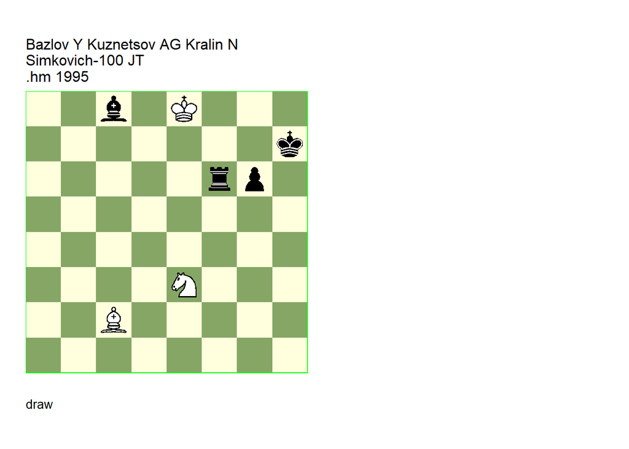

GBR: =0341.01e8h7 U3 FEN: 2b1K3/7k/5rp1/8/8/4N3/2B5/8 w - - 0 1

Bazlov=Y Kuznetsov=AG Kralin=N. (EG#10428). U3: Hergert=V beatochess 11/11/2025. **1. Nd5 Rc6** (1… Re6+! **cook** VH 2. Ne7 (2. Kf7 Rc6 3. Nf6+ Kh6 -+) 2… Kg7 -+) **2. Bxg6+ Rxg6** (2… Kxg6 3. Ne7+) **3. Ne7 Re6 4. Kf7 Bd7 5. Ng8** (5. Nd5? Kh6 6. Nf6 Bc8 7. Ng8+ Kg5 8. Ne7 Bd7) **5… Kh8 6. Ne7 Kh7** ( 6… Rd6 7. Ng6+ Kh7 8. Nf8+ Kh6 9. Ke7) **7. Ng8 Bc8 8. Ne7 Bd7 9. Ng8 1/2-1/2**.

### 3.2.8 Kratz +0010.14b8a6 (2004). Cook (VH)

**4. Ka7** cooks the study.

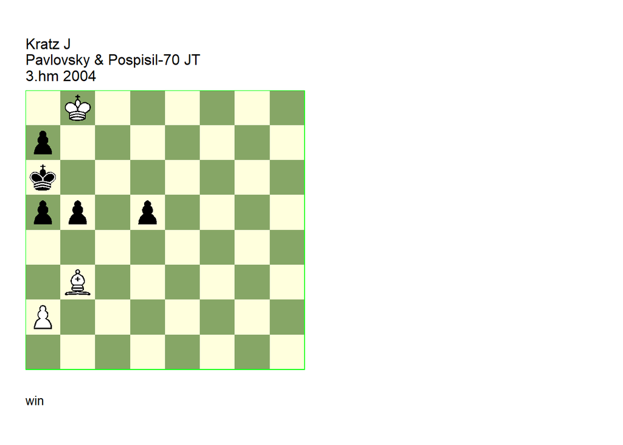

GBR: +0010.14b8a6 U2 FEN: 1K6/p7/k7/pp1p4/8/1B6/P7/8 w - - 0 1

(EG#14725). U2: Hergert=V beatochess beatochess 10/11/2025. **1. Kc7** (1. Bxd5? Kb6!) **1… a4** (1… b4 2. Ba4 b3 3. Kc6 b2 4. Bb5#) (1… d4 2. a4 d3 3. Kc6 d2 4. axb5#) **2. Bxd5 Ka5** (2… b4 3. Kc6 Ka5 4. Kc5 a6 5. Kc4 b3 6. a3 b2 7. Be4) **3. Kb7!** (3. Kc6? Kb4 4. Be6 a6! 5. Kb6 Ka3 6. Kxa6 b4) **3… a6** ( 3… Kb4 4. Ka6! (4. Kxa7? Ka3) (4. Kc6? a6) 4… Kc5 5. Bf7 (5. Be4? Kb4! 6. Bd5 (6. Bb1 Ka3 7. Kxb5 Kb2!) 6… Kc5) 5… b4 (5… Kb4 6. Be6) 6. Ka5 b3 7. a3 b2 8. Ba2 Kd4 9. Kxa4 Kc3 10. Kb5 a6+ 11. Ka5! b1=Q 12. Bxb1 Kb2 13. a4!) (3… b4 4. Kc6 a6 5. Be4! b3 6. a3 b2 7. Kd5!) **4. Be6** (4. Bf7 or ) (4. Bg8 or ) (4. Be4? Kb4! 5. Kxa6 Ka3 6. Bb1 b4!) ( 4. Ka7! **cook** VH 4… b4 5. Bc4 b3 6. a3 b2 7. Bd3 b1=Q 8. Bxb1 +/-) **4… b4** (4… Kb4 5. Kxa6) (4… a3 5. Bb3 b4 6. Bc4!) **5. Bc4!** (5. Kc6? b3 6. a3 b2 7. Ba2 b1=Q 8. Bxb1) (5. Kc7? b3! 6. a3 b2 7. Ba2 Kb5 8. Kd6 b1=Q 9. Bxb1 Kc4 10. Ba2+ Kc3 11. Kc5 Kb2 12. Kb4 Kxa2 13. Kxa4 a5) (5. Bd7? b3 6. a3 b2 7. Bf5 Kb5 8. Bd3+ Kc5 9. Kxa6 Kd4! 10. Bb1 Kc3 11. Ba2 b1=Q 12. Bxb1 Kb3) (5. Bf7? b3 6. a3 b2 7. Ba2 Kb5 8. Ka7 b1=Q 9. Bxb1 Kc4 10. Ba2+ Kc3 11. Kxa6 Kb2 12. Ka5 Kxa3!) (5. Bf5? a3! (5… b3? 6. a3 Kb5 7. Bd3+! Kc5 8. Kxa6) (5… Kb5 6. Bd3+! Kc5 7. Kxa6 Kd4 8. Bb1!) 6. Be6 (6. Bc2 Kb5 7. Bd3+ Kc5! 8. Bc2 Kb5!) 6… Kb5 7. Bf7 (7. Bd7+ Ka5! 8. Be6 Kb5) 7… a5 8. Be8+ Kc4 9. Kb6 Kc3! 10. Ba4 (10. Bf7 a4) 10… Kb2 11. Kxa5 (11. Bb3 a4) 11… Kxa2) **5… b3** (5… a3 6. Kc6 Ka4 (6… b3 7. Bxb3) 7. Kc5) **6. a3 b2 7. Bd3!** (7. Ba2? Kb5!) **7… b1=Q+ 8. Bxb1 Kb5 9. Ba2** (9. Bc2 or ) (9. Bd3+? Ka5 10. Bxa6?) **9… Ka5 10. Kc7! Kb5 11. Kd6 Ka5 12. Kd5 Kb5 13. Bb1 Ka5 14. Kc4 Kb6 15. Kb4 1-0**.